# Calculating Effect Sizes

## 2.169 Someya et al., (1999)

### The effect of cytochrome P450 2D6 genotypes on haloperidol metabolism: A preliminary study in a psychiatric population (Someya et al. 1999)

- This paper looks at the CYP2D6*10 allele and how it affects haloperidol pharmacokinetics.
- Pharamcogenomic information is given as genotypes. These can be converted to metabolism phenotypes as follows:
  - *1/*1 or *1/*10 are NM (groups were merged)
  - *10/*10, *1/*5, and *5/*10 are an IM phenotype (groups were merged)
- Means and SD are provided.
  - Metabolic ratios given as metabolite/drug so converted to drug/metabolite.

```r
someya_b_sig <- readxl::read_xlsx(path = "all_results.xlsx", sheet = 'Someya et al., 1999', col_types = c('text', 'text', 'text', 'text', 'numeric', 'numeric', 'numeric'))

# convert metabolic ratio
someya_b_sig$Genotype[someya_b_sig$Genotype == "*1/*1"] <- "NM"
someya_b_sig$Genotype[someya_b_sig$Genotype == "*1/*10"] <- "NM"
someya_b_sig$Genotype[someya_b_sig$Genotype == "*10/*10"] <- "IM"
someya_b_sig$Genotype[someya_b_sig$Genotype == "*1/*5, *5,*10"] <- "IM"

# join group means and sd (IM)
s_IM <- filter(someya_b_sig, Genotype == "IM")
s_IMa <- filter(s_IM, Notes == "Drug concentration")
s_IMb <- filter(s_IM, Notes == "Metabolite concentration")
s_IMc <- filter(s_IM, Notes == "Metabolic Ratio")

dfs <- list(s_IMa, s_IMb, s_IMc)

ims <- dfs %>% map_dfr(join_means)

# join group means and sd (NM)
s_NM <- filter(someya_b_sig, Genotype == "NM")
s_NMa <- filter(s_NM, Notes == "Drug concentration")
s_NMb <- filter(s_NM, Notes == "Metabolite concentration")
s_NMc <- filter(s_NM, Notes == "Metabolic Ratio")

dfs <- list(s_NMa, s_NMb, s_NMc)

nms <- dfs %>% map_dfr(join_means)

colnames(nms) <- c("Genotype", "Drug", "Notes", "Enzyme", "grp2m", "grp2sd", "grp2n")

someya_b_sig <- cbind(ims,nms[5:7])

someya_b_sig <- check_n(someya_b_sig) %>% na.omit()

# metabolic ratios
# convert to drug/metabolite for group 1
someya_b_sig$grp1mc <- someya_b_sig$grp1m
someya_b_sig$grp1sdc <- someya_b_sig$grp1sd

someya_b_sig$grp1mc[someya_b_sig$Notes == "Metabolic Ratio"] <- exp(log(someya_b_sig$grp1mc[someya_b_sig$Notes == "Metabolic Ratio"])*-1)
someya_b_sig$grp1sdc[someya_b_sig$Notes == "Metabolic Ratio"] <- exp(log(someya_b_sig$grp1sdc[someya_b_sig$Notes == "Metabolic Ratio"])*-1)

# convert to drug/metabolite for group 2
someya_b_sig$grp2mc <- someya_b_sig$grp2m
someya_b_sig$grp2sdc <- someya_b_sig$grp2sd

someya_b_sig$grp2mc[someya_b_sig$Notes == "Metabolic Ratio"] <- exp(log(someya_b_sig$grp2mc[someya_b_sig$Notes == "Metabolic Ratio"])*-1)
someya_b_sig$grp2sdc[someya_b_sig$Notes == "Metabolic Ratio"] <- exp(log(someya_b_sig$grp2sdc[someya_b_sig$Notes == "Metabolic Ratio"])*-1)


someya_b_smd <- NULL

for (i in 1:nrow(someya_b_sig)){
  res <- esc_mean_sd(grp1m = someya_b_sig$grp1mc[i], grp2m = someya_b_sig$grp2mc[i],
                     grp1sd = someya_b_sig$grp1sdc[i], grp2sd = someya_b_sig$grp2sdc[i],
                     grp1n = someya_b_sig$grp1n[i], grp2n = someya_b_sig$grp2n[i], study = paste0(someya_b_sig$Notes[i], " (", someya_b_sig$Drug[i], ") ", ": ", someya_b_sig$Enzyme[i], " ", someya_b_sig$Genotype[i]) )
  someya_b_smd <- rbind(someya_b_smd, data.frame(Analysis = res$study,
                                             Total_N = res$totaln,
                                             SMD = res$es,
                                             SE = res$se,
                                             Var = res$var,
                                             CI_low =  res$ci.lo,
                                             CI_up = res$ci.hi,
                                             Weight =  res$w))
}



DT::datatable(someya_b_smd) %>% formatRound(c('SMD', 'SE', 'Var', 'CI_low', 'CI_up', 'Weight'), 2)
```

|  | Analysis | Total_N | SMD | SE | Var | CI_low | CI_up | Weight |
| --- | --- | --- | --- | --- | --- | --- | --- | --- |
| 1 | Drug concentration (Haloperidol) : CYP2D6 IM | 32 | 0.5319916671721435 | 0.3871390666444905 | 0.1498766569223673 | -0.2267869604595094 | 1.290770294803796 | 6.672153092645892 |
| 2 | Metabolite concentration (Haloperidol) : CYP2D6 IM | 32 | 0.9415487337647857 | 0.3991319668814318 | 0.1593063269866403 | 0.1592644535985459 | 1.723833013931025 | 6.277214589749857 |
| 3 | Metabolic Ratio (Haloperidol) : CYP2D6 IM | 32 | -0.3167246290153132 | 0.3834344264285085 | 0.1470219593705593 | -1.068242295247963 | 0.4347930372173364 | 6.801705026114941 |

```r
someya_b_smd$Study <- "Someya et al., 1999"

rm(s_IM, s_IMa, s_IMb, s_IMc, s_NM, s_NMa, s_NMb, s_NMc, dfs, nms, ims)
```

## 2.170 Suzuki et al., (1998)

### Effects of various factors including the CYP2D6 genotype and coadministration of flunitrazepam on the steady-state plasma concentrations of bromperidol and its reduced metabolite (A. Suzuki et al. 1998)

- This study looks at bromperidol metabolism in people with schizophrenia.
- Pharmacogenomic information is given as number of mutated alleles. These cannot be converted to metabolism phenotypes given that the reduced and null function alleles are classified the same way. Therefore, information has been left in its original format. Comparisons made to people with 0 mutated alleles (i.e., *1/*1)
- Results are given as mean and SD.

```r
suzuki_f_sig <- readxl::read_xlsx(path = "all_results.xlsx", sheet = 'Suzuki et al., 1998', col_types = c('text', 'text', 'text', 'text', 'numeric', 'numeric', 'numeric', 'numeric', 'numeric', 'numeric'))

suzuki_f_sig <- check_n(suzuki_f_sig) %>% na.omit()

suzuki_f_smd <- NULL


for (i in 1:nrow(suzuki_f_sig)){
  res <- esc_mean_sd(grp1m = suzuki_f_sig$grp1m[i], grp2m = suzuki_f_sig$grp2m[i],
                     grp1sd = suzuki_f_sig$grp1sd[i], grp2sd = suzuki_f_sig$grp2sd[i],
                     grp1n = suzuki_f_sig$grp1n[i], grp2n = suzuki_f_sig$grp2n[i], study = paste0(suzuki_f_sig$Notes[i], " (", suzuki_f_sig$Drug[i], ") ", ": ", suzuki_f_sig$Enzyme[i], " ",  suzuki_f_sig$Genotype[i]) )
  suzuki_f_smd <- rbind(suzuki_f_smd, data.frame(Analysis = res$study,
                                             Total_N = res$totaln,
                                             SMD = res$es,
                                             SE = res$se,
                                             Var = res$var,
                                             CI_low =  res$ci.lo,
                                             CI_up = res$ci.hi,
                                             Weight =  res$w))
}

DT::datatable(suzuki_f_smd) %>% formatRound(c('SMD', 'SE', 'Var', 'CI_low', 'CI_up', 'Weight'), 2)
```

|  | Analysis | Total_N | SMD | SE | Var | CI_low | CI_up | Weight |
| --- | --- | --- | --- | --- | --- | --- | --- | --- |
| 1 | Drug Css (Bromperidol) : CYP2D6 1 mutated allele | 58 | 0.02741435226245698 | 0.2627814641457176 | 0.06905409789856708 | -0.487627853267853 | 0.542456557792767 | 14.48139980727705 |
| 2 | Metabolite Css (Bromperidol) : CYP2D6 1 mutated allele | 58 | -0.1497861723788194 | 0.2631369072489627 | 0.0692410319565492 | -0.6655250335900429 | 0.3659526888324041 | 14.442303526434 |

```r
suzuki_f_smd$Study <- "Suzuki et al., 1998"
```

## 2.171 Tiwari et al., (2005b)

### Genetic susceptibility to tardive dyskinesia in chronic schizophrenia subjects: III. Lack of association of CYP3A4 and CYP2D6 gene polymorphisms (Arun K. Tiwari et al. 2005)

- This paper looks at variation in CYP2D6 and risk for ADRs.
- Pharmacogenomic information is reported as genotypes, which can be converted to metabolism phenotypes. Insufficient N for other comparisons.
- Means and SD were used to calculate the SMD.

```r
tiwari_b_sig <- readxl::read_xlsx(path = "all_results.xlsx", sheet = 'Tiwari et al., 2005b', col_types = c('text', 'text', 'text', 'text', 'numeric', 'numeric', 'numeric', 'numeric', 'numeric', 'numeric'))

tiwari_b_sig <- check_n(tiwari_b_sig) %>% na.omit()

# convert metabolism phenotypes
tiwari_b_sig$Genotype[tiwari_b_sig$Genotype == "*1/*4"] <- "IM"

tiwari_b_smd <- NULL

for (i in 1:nrow(tiwari_b_sig)){
  res <- esc_mean_sd(grp1m = tiwari_b_sig$grp1m[i], grp2m = tiwari_b_sig$grp2m[i],
                     grp1sd = tiwari_b_sig$grp1sd[i], grp2sd = tiwari_b_sig$grp2sd[i],
                     grp1n = tiwari_b_sig$grp1n[i], grp2n = tiwari_b_sig$grp2n[i], study = paste0(tiwari_b_sig$Notes[i], " (", tiwari_b_sig$Drug[i], ") ", ": ", tiwari_b_sig$Enzyme[i], " ", tiwari_b_sig$Genotype[i]) )
  tiwari_b_smd <- rbind(tiwari_b_smd, data.frame(Analysis = res$study,
                                             Total_N = res$totaln,
                                             SMD = res$es,
                                             SE = res$se,
                                             Var = res$var,
                                             CI_low =  res$ci.lo,
                                             CI_up = res$ci.hi,
                                             Weight =  res$w))
}



DT::datatable(tiwari_b_smd) %>% formatRound(c('SMD', 'SE', 'Var', 'CI_low', 'CI_up', 'Weight'), 2)
```

|  | Analysis | Total_N | SMD | SE | Var | CI_low | CI_up | Weight |
| --- | --- | --- | --- | --- | --- | --- | --- | --- |
| 1 | ADR AIMS score (Antipsychotics) : CYP2D6 IM | 90 | 0.2676354831489783 | 0.2835453006315294 | 0.08039793751022438 | -0.2881030940744014 | 0.823374060372358 | 12.43813001885562 |

```r
tiwari_b_smd$Study <- "Tiwari et al., 2005b"
```

## 2.172 Topić et al., (2000)

### CYP2D6 Genotyping in Patients on Psychoactive Drug Therapy (Topić et al. 2000)

- This paper also looks at CYP2D6 variation and ADR risk.
- Pharmacogenomic information is given as metabolism phenotypes.
- Results are reported as observations, which were used to calculate the SMD.

```r
topic_sig <- readxl::read_xlsx(path = "all_results.xlsx", sheet = 'Topic et al., 2000', col_types = c('text', 'text', 'text', 'text', 'numeric', 'numeric', 'numeric', 'numeric', 'numeric', 'numeric'))

topic_sig <- check_n(topic_sig) %>% na.omit()

topic_smd <- NULL

for (i in 1:nrow(topic_sig)){
  res <- esc_2x2(grp1yes = topic_sig$grp1.y[i], grp1no = topic_sig$grp1.n[i], grp2yes = topic_sig$grp2.y[i], grp2no = topic_sig$grp2.n[i], es.type = "d", study = paste0(topic_sig$Notes[i], " (", topic_sig$Drug[i], ") ", ": ", topic_sig$Enzyme[i], " ", topic_sig$Genotype[i]))
  topic_smd <- rbind(topic_smd, data.frame(Analysis = res$study,
                                             Total_N = res$totaln,
                                             SMD = res$es,
                                             SE = res$se,
                                             Var = res$var,
                                             CI_low =  res$ci.lo,
                                             CI_up = res$ci.hi,
                                             Weight =  res$w))
}


DT::datatable(topic_smd) %>% formatRound(c('SMD', 'SE', 'Var', 'CI_low', 'CI_up', 'Weight'), 2)
```

|  | Analysis | Total_N | SMD | SE | Var | CI_low | CI_up | Weight |
| --- | --- | --- | --- | --- | --- | --- | --- | --- |
| 1 | ADR: TD (Psychiatric medication) : CYP2D6 IM | 58 | 0.4262819270310643 | 0.3127521573081027 | 0.09781391190087223 | -0.1867010373800224 | 1.039264891442151 | 10.22349459873798 |
| 2 | ADR: TD (Psychiatric medication) : CYP2D6 PM | 44 | 1.313611553543312 | 0.6338591821752569 | 0.4017774628278856 | 0.07127038520979556 | 2.555952721876828 | 2.488940004154445 |

```r
topic_smd$Study <- "Topić et al., 2000"
```

## 2.173 Uckun et al., (2015)

### The impact of CYP2C19 polymorphisms on citalopram metabolism in patients with major depressive disorder (Uckun et al. 2015)

```r
uckun_sig <- readxl::read_xlsx(path = "all_results.xlsx", sheet = 'Uckun et al., 2015', col_types = c('text', 'text', 'text', 'text', 'numeric', 'numeric', 'numeric', 'numeric', 'numeric', 'numeric'))

# convert metabolism phenotypes
uckun_sig$Genotype[uckun_sig$Genotype == "*1/*2"] <- "IM"
uckun_sig$Genotype[uckun_sig$Genotype == "*2/*17"] <- "IM"
uckun_sig$Genotype[uckun_sig$Genotype == "*1/*17"] <- "RM"

rm <- filter(uckun_sig, Genotype == "RM")

# join group means and sd (IM)
s_IM <- filter(uckun_sig, Genotype == "IM")
s_IMa <- filter(s_IM, Notes == "Dose")
s_IMb <- filter(s_IM, Notes == "Drug concentration")
s_IMc <- filter(s_IM, Notes == "Metabolite concentration")
s_IMd <- filter(s_IM, Notes == "Metabolic Ratio")
s_IMe <- filter(s_IM, Notes == "C/D Metabolite concentration")

dfs <- list(s_IMa, s_IMb, s_IMc, s_IMd, s_IMe)

ims <- dfs %>% map_dfr(join_means)

uckun_sig <- rbind(ims, rm)

uckun_sig <- check_n(uckun_sig) %>% na.omit()

uckun_smd <- NULL

for (i in 1:nrow(uckun_sig)){
  res <- esc_mean_sd(grp1m = uckun_sig$grp1m[i], grp2m = uckun_sig$grp2m[i],
                     grp1sd = uckun_sig$grp1sd[i], grp2sd = uckun_sig$grp2sd[i],
                     grp1n = uckun_sig$grp1n[i], grp2n = uckun_sig$grp2n[i], study = paste0(uckun_sig$Notes[i], " (", uckun_sig$Drug[i], ") ", ": ", uckun_sig$Enzyme[i], " ", uckun_sig$Genotype[i]) )
  uckun_smd <- rbind(uckun_smd, data.frame(Analysis = res$study,
                                             Total_N = res$totaln,
                                             SMD = res$es,
                                             SE = res$se,
                                             Var = res$var,
                                             CI_low =  res$ci.lo,
                                             CI_up = res$ci.hi,
                                             Weight =  res$w))
}



DT::datatable(uckun_smd) %>% formatRound(c('SMD', 'SE', 'Var', 'CI_low', 'CI_up', 'Weight'), 2)
```

|  | Analysis | Total_N | SMD | SE | Var | CI_low | CI_up | Weight |
| --- | --- | --- | --- | --- | --- | --- | --- | --- |
| 1 | Dose (Citalopram) : CYP2C19 IM | 33 | -0.2302861889701578 | 0.3918944868464759 | 0.1535812888206626 | -0.9983852689290562 | 0.5378128909887407 | 6.511209846452735 |
| 2 | Drug concentration (Citalopram) : CYP2C19 IM | 33 | -0.3509686223488871 | 0.3932481733800805 | 0.1546441258667698 | -1.121720879160008 | 0.4197836344622333 | 6.46645964982548 |
| 3 | Metabolite concentration (Citalopram) : CYP2C19 IM | 33 | -1.036147903933053 | 0.4111501939710072 | 0.1690444820023969 | -1.841987476352884 | -0.2303083315132216 | 5.915602734585688 |
| 4 | Metabolic Ratio (Citalopram) : CYP2C19 IM | 33 | 1.294651936360921 | 0.4221061364743939 | 0.1781735904493397 | 0.4673391112177607 | 2.121964761504082 | 5.612504061225231 |
| 5 | C/D Metabolite concentration (Citalopram) : CYP2C19 IM | 33 | -1.03856817302232 | 0.411242706177343 | 0.1691205633840644 | -1.8445890660347 | -0.2325472800099403 | 5.912941513380897 |
| 6 | Dose (Citalopram) : CYP2C19 RM | 40 | -0.1826649640371669 | 0.3233941059763619 | 0.1045837477802504 | -0.8165057645633655 | 0.4511758364890317 | 9.561715096509861 |
| 7 | Drug concentration (Citalopram) : CYP2C19 RM | 40 | -0.07180190350314089 | 0.3228484328342018 | 0.1042311105835001 | -0.7045732043233749 | 0.5609693973170932 | 9.594064520677774 |
| 8 | Metabolite concentration (Citalopram) : CYP2C19 RM | 40 | -0.2924769587261411 | 0.3244009113874186 | 0.1052359513089878 | -0.9282910615974509 | 0.3433371441451687 | 9.502456029155443 |
| 9 | Metabolic Ratio (Citalopram) : CYP2C19 RM | 40 | 0.4910101943391704 | 0.3273840318394882 | 0.1071803043034791 | -0.1506507171797408 | 1.132671105858082 | 9.33007240927884 |
| 10 | C/D Metabolite concentration (Citalopram) : CYP2C19 RM | 40 | -0.4214180175641717 | 0.3261695586436035 | 0.1063865809857631 | -1.06069860535896 | 0.2178625702306161 | 9.399681714875507 |

```r
uckun_smd$Study <- "Uckun et al., 2015"

rm(s_IM, s_IMa, s_IMb, s_IMc, s_IMd, s_IMe, dfs, ims, rm)
```

## 2.174 Yasui-Furukori et al., (2003)

### Effects of CYP2D6 Genotypes on Plasma Concentrations of Risperidone and Enantiomers of 9-Hydroxyrisperidone in Japanese Patients with Schizophrenia (Yasui-Furukori et al. 2003)

- This paper looks at variation in CYP2D76 and risperidone pharmacokinetics.
- Pharmacogenomic information is given as number of mutated alleles. These cannot be converted to metabolism phenotypes given that the reduced and null function alleles are classified the same way. Therefore, information has been left in its original format. Comparisons made to people with 0 mutated alleles (i.e., *1/*1)
- SMDs were calculated using means and SDs.

```r
yasuifurukori_sig <- readxl::read_xlsx(path = "all_results.xlsx", sheet = 'Yasui-Furukori et al., 2003', col_types = c('text', 'text', 'text', 'text', 'numeric', 'numeric', 'numeric', 'numeric', 'numeric', 'numeric'))

yasuifurukori_sig <- check_n(yasuifurukori_sig) %>% na.omit()

yasuifurukori_smd <- NULL

for (i in 1:nrow(yasuifurukori_sig)){
  res <- esc_mean_sd(grp1m = yasuifurukori_sig$grp1m[i], grp2m = yasuifurukori_sig$grp2m[i],
                     grp1sd = yasuifurukori_sig$grp1sd[i], grp2sd = yasuifurukori_sig$grp2sd[i],
                     grp1n = yasuifurukori_sig$grp1n[i], grp2n = yasuifurukori_sig$grp2n[i], study = paste0(yasuifurukori_sig$Notes[i], " (", yasuifurukori_sig$Drug[i], ") ", ": ", yasuifurukori_sig$Enzyme[i], " ", yasuifurukori_sig$Genotype[i]) )
  yasuifurukori_smd <- rbind(yasuifurukori_smd, data.frame(Analysis = res$study,
                                             Total_N = res$totaln,
                                             SMD = res$es,
                                             SE = res$se,
                                             Var = res$var,
                                             CI_low =  res$ci.lo,
                                             CI_up = res$ci.hi,
                                             Weight =  res$w))
}



DT::datatable(yasuifurukori_smd) %>% formatRound(c('SMD', 'SE', 'Var', 'CI_low', 'CI_up', 'Weight'), 2)
```

|  | Analysis | Total_N | SMD | SE | Var | CI_low | CI_up | Weight |
| --- | --- | --- | --- | --- | --- | --- | --- | --- |
| 1 | Drug concentration (Risperidone) : CYP2D6 WT/MUT | 34 | 1.615029151267545 | 0.3997326683250655 | 0.1597862061262768 | 0.8315675179063223 | 2.398490784628768 | 6.25836249725908 |
| 2 | Metabolite concentration (Risperidone) : CYP2D6 WT/MUT | 34 | 0.385990835395923 | 0.3515957693597214 | 0.1236195850316544 | -0.3031242096657822 | 1.075105880457628 | 8.089333091871623 |
| 3 | Metabolic Ratio (Risperidone) : CYP2D6 WT/MUT | 34 | 0.9536837846062404 | 0.3671563142459124 | 0.1348037590906432 | 0.2340706319877818 | 1.673296937224699 | 7.418190759262072 |

```r
yasuifurukori_smd$Study <- "Yasui-Furukori et al., 2003"
```

## 2.175 Walden et al., (2019)

### Genetic testing for CYP2D6 and CYP2C19 suggests improved outcome for antidepressant and antipsychotic medication (Walden et al. 2019)

- This paper looks at CYP2D6 variation and risk for side effects in people taking psychiatric drugs.
- Pharmacogenomic information was given as metabolism phenotype that had been corrected for phenoconversion (for CYP2D6, no inducers/inhibitors of CYP2C19 were present).
- Raw scores per participants are given in the supplemental materials. These were used to calculate mean and SD, and then the SMD.
  - where CYP2C19 EM-UM intermediate reported, termed ‘RM’
  - participants with other non-traditional (i.e., anything other than PM, IM, EM, RM, UM) phenotypes reported were excluded

```r
walden_sig <- readxl::read_xlsx(path = "all_results.xlsx", sheet = 'Walden et al., 2019', col_types = c('text', 'text', 'text', 'text', 'numeric', 'numeric', 'numeric', 'numeric', 'numeric', 'numeric'))

walden_sig <- check_n(walden_sig) %>% na.omit()

walden_smd <- NULL

for (i in 1:nrow(walden_sig)){
  res <- esc_mean_sd(grp1m = walden_sig$grp1m[i], grp2m = walden_sig$grp2m[i],
                     grp1sd = walden_sig$grp1sd[i], grp2sd = walden_sig$grp2sd[i],
                     grp1n = walden_sig$grp1n[i], grp2n = walden_sig$grp2n[i], study = paste0(walden_sig$Notes[i], " (", walden_sig$Drug[i], ") ", ": ", walden_sig$Enzyme[i], " ", walden_sig$Genotype[i]) )
  walden_smd <- rbind(walden_smd, data.frame(Analysis = res$study,
                                             Total_N = res$totaln,
                                             SMD = res$es,
                                             SE = res$se,
                                             Var = res$var,
                                             CI_low =  res$ci.lo,
                                             CI_up = res$ci.hi,
                                             Weight =  res$w))
}



DT::datatable(walden_smd) %>% formatRound(c('SMD', 'SE', 'Var', 'CI_low', 'CI_up', 'Weight'), 2)
```

|  | Analysis | Total_N | SMD | SE | Var | CI_low | CI_up | Weight |
| --- | --- | --- | --- | --- | --- | --- | --- | --- |
| 1 | ADR UKU Total (Psychiatric medication) : CYP2D6 IM | 58 | 0.3002412943001179 | 0.3487268902424745 | 0.1216104439781869 | -0.3832508510157844 | 0.9837334396160202 | 8.222977955572377 |
| 2 | ADR UKU Psychic (Psychiatric medication) : CYP2D6 IM | 58 | 0.5973442117525858 | 0.3520076259702556 | 0.1239093687412154 | -0.09257805743256131 | 1.287266480937733 | 8.070414772982172 |
| 3 | ADR UKU Autonomic (Psychiatric medication) : CYP2D6 IM | 58 | -0.01216184586095009 | 0.3476127276493272 | 0.1208346084238053 | -0.6934702726213617 | 0.6691465808994617 | 8.275774739077095 |
| 4 | ADR UKU Total (Psychiatric medication) : CYP2C19 IM | 66 | 0.423759270033 | 0.2838874530555472 | 0.08059208600236553 | -0.1326499136186778 | 0.9801684536846778 | 12.40816623074688 |
| 5 | ADR UKU Total (Psychiatric medication) : CYP2C19 RM | 54 | -0.1201448773309181 | 0.4696188015216282 | 0.2205418187426104 | -1.040580814776173 | 0.8002910601143368 | 4.534287445806722 |
| 6 | ADR UKU Psychic (Psychiatric medication) : CYP2C19 IM | 66 | 0.6087123307960994 | 0.2864240622699963 | 0.08203874344724674 | 0.04733148444124902 | 1.17009317715095 | 12.18936270815787 |
| 7 | ADR UKU Psychic (Psychiatric medication) : CYP2C19 RM | 54 | -0.2258207783258421 | 0.4699790840162439 | 0.2208803394127477 | -1.146962856484804 | 0.69532129983312 | 4.527338207912437 |
| 8 | ADR UKU Autonomic (Psychiatric medication) : CYP2C19 IM | 66 | 0.1439006896723295 | 0.2817597682136316 | 0.0793885669837994 | -0.4083383083187418 | 0.6961396876634008 | 12.59627220886941 |
| 9 | ADR UKU Autonomic (Psychiatric medication) : CYP2C19 RM | 54 | -0.003216024654475988 | 0.4694765798547439 | 0.2204082590321078 | -0.9233732127548167 | 0.9169411634458646 | 4.537035065706525 |

```r
walden_smd$Study <- "Walden et al., 2019"
```

## 2.176 Fabbri et al., (2018)

### Effect of cytochrome *CYP2C19* metabolizing activity on antidepressant response and side effects: Meta-analysis of data from genome-wide association studies (Fabbri et al. 2018)

- This analysis looks at CYP2C19 variation and remission in people taking antidepressants.
- Pharmacogenomic information is reported as metabolism phenotypes.
- Results are reported as OR and CI for remission. Comparisons between time points were excluded.

```r
fabbri_sig <- readxl::read_xlsx(path = "all_results.xlsx", sheet = 'Fabbri et al., 2018', col_types = c('text', 'text', 'text', 'text', 'numeric', 'numeric', 'numeric', 'numeric'))

fabbri_sig <- check_n(fabbri_sig) %>% na.omit()

# calc SE from CI (OR)
fabbri_sig$ln.CI.hi <- log(fabbri_sig$CI.hi)
fabbri_sig$ln.CI.lo <- log(fabbri_sig$CI.lo)
fabbri_sig$ln.SE <- ((fabbri_sig$ln.CI.hi-fabbri_sig$ln.CI.lo)/3.92)

fabbri_smd <- NULL

for (i in 1:nrow(fabbri_sig)){
  res <- convert_or2d(or = fabbri_sig$OR[i], se = fabbri_sig$ln.SE[i], study = paste0(fabbri_sig$Notes[i], " (", fabbri_sig$Drug[i], ") ", ": ", fabbri_sig$Enzyme[i], " ", fabbri_sig$Genotype[i]) )
  fabbri_smd <- rbind(fabbri_smd, data.frame(Analysis = res$study,
                                           Total_N = fabbri_sig$N[i],
                                           SMD = res$es,
                                           SE = res$se,
                                           Var = res$var,
                                           CI_low =  res$ci.lo,
                                           CI_up = res$ci.hi,
                                           Weight =  res$w))
}




DT::datatable(fabbri_smd) %>% formatRound(c('SMD', 'SE', 'Var', 'CI_low', 'CI_up', 'Weight'), 2)
```

|  | Analysis | Total_N | SMD | SE | Var | CI_low | CI_up | Weight |
| --- | --- | --- | --- | --- | --- | --- | --- | --- |
| 1 | Remission (Antidepressants) : CYP2C19 PM | 2588 | 0.2416226069834276 | 0.06553082647184337 | 0.004294289218082848 | 0.1131845472214707 | 0.3700606667453846 | 232.8674081356919 |
| 2 | Remission (Antidepressants) : CYP2C19 IM | 2588 | 0.05254725615397086 | 0.03678867628972984 | 0.00135340670315053 | -0.01955722441280223 | 0.1246517367207439 | 738.876198612101 |
| 3 | Remission (Antidepressants) : CYP2C19 RM | 2588 | 0.03730216792879967 | 0.03285679026939428 | 0.001079568666806963 | -0.02709595764679921 | 0.1017002935043985 | 926.295872366968 |
| 4 | Remission (Antidepressants) : CYP2C19 UM | 2588 | 0 | 0.06787286424901641 | 0.00460672570136541 | -0.1330283694556484 | 0.1330283694556484 | 217.0739186193797 |

```r
fabbri_smd$Study <- "Fabbri et al., 2018"
```

## 2.177 Chen et al., (2017)

### Polymorphism in CYP2D6 affects the pharmacokinetics and dose escalation of paroxetine controlled-release tablet in healthy Chinese subjects (R. Chen, Shen, and Huâ© 2017)

- This analysis looks at CYP2D6 variation on pharmacokinetic parameters at different doses.
- Pharmacogenomic information is reported as metabolism phenotypes.
- Results are reported as mean and SD. Geometric means are reported also in the paper but we did not include these.

```r
chen_b_sig <- readxl::read_xlsx(path = "all_results.xlsx", sheet = 'Chen et al., 2017', col_types = c('text', 'text', 'text', 'text', 'numeric', 'numeric', 'numeric', 'numeric', 'numeric', 'numeric'))

chen_b_sig <- check_n(chen_b_sig) %>% na.omit()

chen_b_smd <- NULL

for (i in 1:nrow(chen_b_sig)){
  res <- esc_mean_sd(grp1m = chen_b_sig$grp1m[i], grp2m = chen_b_sig$grp2m[i],
                     grp1sd = chen_b_sig$grp1sd[i], grp2sd = chen_b_sig$grp2sd[i],
                     grp1n = chen_b_sig$grp1n[i], grp2n = chen_b_sig$grp2n[i], study = paste0(chen_b_sig$Notes[i], " (", chen_b_sig$Drug[i], ") ", ": ", chen_b_sig$Enzyme[i], " ", chen_b_sig$Genotype[i]) )
  chen_b_smd <- rbind(chen_b_smd, data.frame(Analysis = res$study,
                                             Total_N = res$totaln,
                                             SMD = res$es,
                                             SE = res$se,
                                             Var = res$var,
                                             CI_low =  res$ci.lo,
                                             CI_up = res$ci.hi,
                                             Weight =  res$w))
}



DT::datatable(chen_b_smd) %>% formatRound(c('SMD', 'SE', 'Var', 'CI_low', 'CI_up', 'Weight'), 2)
```

|  | Analysis | Total_N | SMD | SE | Var | CI_low | CI_up | Weight |
| --- | --- | --- | --- | --- | --- | --- | --- | --- |
| 1 | Drug T1/2 at 12.5mg (Paroxetine) : CYP2D6 IM | 12 | 0.8860320353165286 | 0.6128357649817561 | 0.3755676748407741 | -0.3151039924857658 | 2.087168063118823 | 2.662635969466649 |
| 2 | Drug T1/2 at 25mg (Paroxetine) : CYP2D6 IM | 12 | 2.144863136962343 | 0.7311238297098792 | 0.5345420543696405 | 0.7118867624919847 | 3.577839511432702 | 1.870760198987994 |
| 3 | Drug T1/2 at 37.5mg (Paroxetine) : CYP2D6 IM | 12 | 0.5240183849312471 | 0.5952298819334909 | 0.3542986123465576 | -0.6426107461804235 | 1.690647516042918 | 2.822477890548013 |
| 4 | Drug tmax at 12.5mg (Paroxetine) : CYP2D6 IM | 12 | 0.5724245827291315 | 0.5970846300806126 | 0.3565100554785021 | -0.5978397879512899 | 1.742688953409553 | 2.804969971065237 |
| 5 | Drug tmax at 25mg (Paroxetine) : CYP2D6 IM | 12 | 0.1455556274348958 | 0.5862933661732195 | 0.3437399112187248 | -1.003558254639368 | 1.29466950950916 | 2.909176291035029 |
| 6 | Drug tmax at 37.5mg (Paroxetine) : CYP2D6 IM | 12 | 0.4226703189250703 | 0.591862231543782 | 0.3503009011279854 | -0.7373583387102486 | 1.582698976560389 | 2.854688631345089 |
| 7 | Drug Cmax at 12.5mg (Paroxetine) : CYP2D6 IM | 12 | 2.301726943053969 | 0.7507362594189342 | 0.5636049312063333 | 0.8303109127045394 | 3.773142973403399 | 1.774292495737417 |
| 8 | Drug Cmax at 25mg (Paroxetine) : CYP2D6 IM | 12 | 1.580083212632537 | 0.6684944024763966 | 0.4468847661422745 | 0.2698582599121764 | 2.890308165352897 | 2.237713334093896 |
| 9 | Drug Cmax at 37.5mg (Paroxetine) : CYP2D6 IM | 12 | 2.204225901579237 | 0.7384438382437599 | 0.5452993022401762 | 0.7569025740159467 | 3.651549229142527 | 1.833855271576254 |
| 10 | Drug AUC0-t at 12.5mg (Paroxetine) : CYP2D6 IM | 12 | 2.22028621973197 | 0.7404458771044397 | 0.5482600969209629 | 0.7690389681060974 | 3.671533471357842 | 1.823951817059121 |

[output cut: 11 more lines]

```r
chen_b_smd$Study <- "Chen et al., 2017"
```

## 2.178 Suzuki et al., (2024)

### 2.178.1 CYP1A2*F Polymorphism Contributes at Least Partially to the Variability of Plasma Levels of Dehydroaripiprazole, an Active Metabolite of Aripiprazole, in Schizophrenic Patients (T. Suzuki et al. 2024) {-}

- This paper looks at CYP1A2 variation and aripiprazole pharmacokinetics.
- Pharmacogenomic information is given as genotypes.
- Results are reported as means and SD.

```r
suzuki_g_sig <- readxl::read_xlsx(path = "all_results.xlsx", sheet = 'Suzuki et al., 2024', col_types = c('text', 'text', 'text', 'text', 'numeric', 'numeric', 'numeric', 'numeric', 'numeric', 'numeric'))

suzuki_g_sig <- check_n(suzuki_g_sig) %>% na.omit()

suzuki_g_smd <- NULL

for (i in 1:nrow(suzuki_g_sig)){
  res <- esc_mean_sd(grp1m = suzuki_g_sig$grp1m[i], grp2m = suzuki_g_sig$grp2m[i],
                     grp1sd = suzuki_g_sig$grp1sd[i], grp2sd = suzuki_g_sig$grp2sd[i],
                     grp1n = suzuki_g_sig$grp1n[i], grp2n = suzuki_g_sig$grp2n[i], study = paste0(suzuki_g_sig$Notes[i], " (", suzuki_g_sig$Drug[i], ") ", ": ", suzuki_g_sig$Enzyme[i], " ", suzuki_g_sig$Genotype[i]) )
  suzuki_g_smd <- rbind(suzuki_g_smd, data.frame(Analysis = res$study,
                                             Total_N = res$totaln,
                                             SMD = res$es,
                                             SE = res$se,
                                             Var = res$var,
                                             CI_low =  res$ci.lo,
                                             CI_up = res$ci.hi,
                                             Weight =  res$w))
}

DT::datatable(suzuki_g_smd) %>% formatRound(c('SMD', 'SE', 'Var', 'CI_low', 'CI_up', 'Weight'), 2)
```

|  | Analysis | Total_N | SMD | SE | Var | CI_low | CI_up | Weight |
| --- | --- | --- | --- | --- | --- | --- | --- | --- |
| 1 | C/D Drug concentration (Aripiprazole) : CYP1A2 *1/*1C | 86 | -0.07763944400712133 | 0.2162733831698273 | 0.04677417626772293 | -0.5015274858346138 | 0.3462485978203711 | 21.37931824338854 |
| 2 | C/D Metabolite concentration (Aripiprazole) : CYP1A2 *1/*1C | 86 | 0 | 0.2161923459209012 | 0.04673913043478261 | -0.4237292117381911 | 0.4237292117381911 | 21.3953488372093 |
| 3 | Metabolic Ratio (Aripiprazole) : CYP1A2 *1/*1C | 86 | -0.04241838790270131 | 0.2162165386723118 | 0.04674959159543531 | -0.4661950165623441 | 0.3813582407569415 | 21.3905611979216 |
| 4 | C/D Drug concentration (Aripiprazole) : CYP1A2 *1/*1F | 57 | -0.1038186812779916 | 0.289686168233824 | 0.08391807606599541 | -0.6715931378356976 | 0.4639557752797145 | 11.91638377426067 |
| 5 | C/D Drug concentration (Aripiprazole) : CYP1A2 *1F/*1F | 49 | -0.5562477626669988 | 0.305337174883048 | 0.09323079036556105 | -1.154697628578981 | 0.04220210324498308 | 10.72607017573236 |
| 6 | C/D Metabolite concentration (Aripiprazole) : CYP1A2 *1/*1F | 57 | -0.1628383193520103 | 0.2899243499512486 | 0.08405612869465406 | -0.7310796034976443 | 0.4054029647936239 | 11.89681246958973 |
| 7 | C/D Metabolite concentration (Aripiprazole) : CYP1A2 *1F/*1F | 49 | -0.7954311462779512 | 0.3106923898823991 | 0.0965297611308367 | -1.40437704071813 | -0.1864852518377724 | 10.35949937392466 |
| 8 | Metabolic Ratio (Aripiprazole) : CYP1A2 *1/*1F | 57 | -0.12926423026528 | 0.2897759508710506 | 0.0839701017032215 | -0.6972146575583871 | 0.4386861970278271 | 11.90900070044378 |
| 9 | Metabolic Ratio (Aripiprazole) : CYP1A2 *1F/*1F | 49 | -0.664349758035381 | 0.3075340778089845 | 0.09457720901382255 | -1.267105474559729 | -0.06159404151103287 | 10.57337185593888 |

```r
suzuki_g_smd$Study <- "Suzuki et al., 2024"
```

## 2.179 Chen et al., (2021)

### Associations of CYP1A2, CYP2D6 and CYP2C19 gene polymorphisms with clozapine and its serum metabolites (Y. Chen et al. 2021)

- This paper looks at variation in various genes and clozapine pharmacokinetics.
- Genotypes reported and compared to wt/wt but combines het- and homo- mutants unfortunately making it difficult to convert to metabolism phenotypes.
- Means and SD are reported and used to calculate the SMD.
  - Metabolic ratio is given as metabolite over drug so convert to drug over metabolite.

```r
chen_c_sig <- readxl::read_xlsx(path = "all_results.xlsx", sheet = 'Chen et al., 2021', col_types = c('text', 'text', 'text', 'text', 'numeric', 'numeric', 'numeric', 'numeric', 'numeric', 'numeric'))

chen_c_sig <- check_n(chen_c_sig) %>% na.omit()

# convert metabolism phenotypes
chen_c_sig$Genotype[chen_c_sig$Genotype == "*1/*3 or *3/*3"] <- "IM/PM"
chen_c_sig$Genotype[chen_c_sig$Genotype == "*1/*2 or *2/*2"  & chen_c_sig$Enzyme == "CYP2C19"] <- "IM/PM"

# convert to drug/metabolite for group 1
chen_c_sig$grp1mc <- chen_c_sig$grp1m
chen_c_sig$grp1mc[chen_c_sig$Notes == "Metabolic Ratio"] <- exp(log(chen_c_sig$grp1mc[chen_c_sig$Notes == "Metabolic Ratio"])*-1)
chen_c_sig$grp1sdc <- chen_c_sig$grp1sd
chen_c_sig$grp1sdc[chen_c_sig$Notes == "Metabolic Ratio"] <- exp(log(chen_c_sig$grp1sdc[chen_c_sig$Notes == "Metabolic Ratio"])*-1)

# convert to drug/metabolite for group 2
chen_c_sig$grp2mc <- chen_c_sig$grp2m
chen_c_sig$grp2mc[chen_c_sig$Notes == "Metabolic Ratio"] <- exp(log(chen_c_sig$grp2mc[chen_c_sig$Notes == "Metabolic Ratio"])*-1)
chen_c_sig$grp2sdc <- chen_c_sig$grp2sd
chen_c_sig$grp2sdc[chen_c_sig$Notes == "Metabolic Ratio"] <- exp(log(chen_c_sig$grp2sdc[chen_c_sig$Notes == "Metabolic Ratio"])*-1)


chen_c_smd <- NULL

for (i in 1:nrow(chen_c_sig)){
  res <- esc_mean_sd(grp1m = chen_c_sig$grp1m[i], grp2m = chen_c_sig$grp2m[i],
                     grp1sd = chen_c_sig$grp1sd[i], grp2sd = chen_c_sig$grp2sd[i],
                     grp1n = chen_c_sig$grp1n[i], grp2n = chen_c_sig$grp2n[i], study = paste0(chen_c_sig$Notes[i], " (", chen_c_sig$Drug[i], ") ", ": ", chen_c_sig$Enzyme[i], " ", chen_c_sig$Genotype[i]) )
  chen_c_smd <- rbind(chen_c_smd, data.frame(Analysis = res$study,
                                             Total_N = res$totaln,
                                             SMD = res$es,
                                             SE = res$se,
                                             Var = res$var,
                                             CI_low =  res$ci.lo,
                                             CI_up = res$ci.hi,
                                             Weight =  res$w))
}

DT::datatable(chen_c_smd) %>% formatRound(c('SMD', 'SE', 'Var', 'CI_low', 'CI_up', 'Weight'), 2)
```

|  | Analysis | Total_N | SMD | SE | Var | CI_low | CI_up | Weight |
| --- | --- | --- | --- | --- | --- | --- | --- | --- |
| 1 | C/D Drug concentration (Clozapine) : CYP1A2 *1/*1C or *1C/*1C | 156 | -0.0981624379375671 | 0.1610729817277146 | 0.0259445054426567 | -0.4138596810063659 | 0.2175348051312317 | 38.54380659559031 |
| 2 | C/D Metabolite concentration (Clozapine) : CYP1A2 *1/*1C or *1C/*1C | 156 | -0.3663653634265303 | 0.1623078095563087 | 0.02634382504296698 | -0.6844828245664814 | -0.04824790228657927 | 37.95955972107286 |
| 3 | Metabolic Ratio (Clozapine) : CYP1A2 *1/*1C or *1C/*1C | 156 | -0.4395000487346523 | 0.1628886882663852 | 0.02653272476514361 | -0.7587560112257392 | -0.1202440862435653 | 37.68930665250458 |
| 4 | C/D Drug concentration (Clozapine) : CYP1A2 *1/*1F or *1F/*1F | 156 | -0.01027617899292353 | 0.2058084372172188 | 0.04235711282979389 | -0.4136533036531451 | 0.393100945667298 | 23.60878570780685 |
| 5 | C/D Metabolite concentration (Clozapine) : CYP1A2 *1/*1F or *1F/*1F | 156 | -0.06404708798186567 | 0.2058395537769707 | 0.04236992189910242 | -0.4674851999785239 | 0.3393910240147925 | 23.60164841420641 |
| 6 | Metabolic Ratio (Clozapine) : CYP1A2 *1/*1F or *1F/*1F | 156 | 0.06319960655494684 | 0.2058387141929525 | 0.04236957626060801 | -0.3402368598872738 | 0.4666360729971674 | 23.60184094948628 |
| 7 | C/D Drug concentration (Clozapine) : CYP2D6 *1/*2 or *2/*2 | 156 | -0.3689156804647837 | 0.1860759205921848 | 0.03462424822422905 | -0.7336177832156008 | -0.004213577713966687 | 28.88149349912033 |
| 8 | C/D Metabolite concentration (Clozapine) : CYP2D6 *1/*2 or *2/*2 | 156 | -0.04505865316538979 | 0.1849176614140958 | 0.03419454150285816 | -0.4074906096423895 | 0.3173733033116098 | 29.24443364495514 |
| 9 | Metabolic Ratio (Clozapine) : CYP2D6 *1/*2 or *2/*2 | 156 | 0.6499616998140012 | 0.188525969763569 | 0.03554204127529415 | 0.2804575889269188 | 1.019465810701084 | 28.13569407154778 |
| 10 | C/D Drug concentration (Clozapine) : CYP2D6 *1/*10 or *10/*10 | 156 | -0.2411718261074371 | 0.3007726722509805 | 0.09046420037299571 | -0.8306754312532285 | 0.3483317790383543 | 11.0540964920584 |

[output cut: 8 more lines]

```r
chen_c_smd$Study <- "Chen et al., 2021"
```

## 2.180 Demirbugen Oz et al., (2023)

### The Potential Role of POR*28 and CYP1A2*F Genetic Variations and Lifestyle Factors on Clozapine and N-DesmethylClozapine Plasma Levels in Schizophrenia Patients (Demirbugen Oz et al. 2023)

- This paper looks at CYP1A2 variation and clozapine metabolism.
- Pharmacogenomic information is given as genotypes for *1F.
- Results are listed as means and SD, which were used to calculate the SMD.

```r
demirbugen_sig <- readxl::read_xlsx(path = "all_results.xlsx", sheet = 'Demirbugen Oz et al., 2023', col_types = c('text', 'text', 'text', 'text', 'numeric', 'numeric', 'numeric', 'numeric', 'numeric', 'numeric'))

demirbugen_sig <- check_n(demirbugen_sig) %>% na.omit()

demirbugen_smd <- NULL

for (i in 1:nrow(demirbugen_sig)){
  res <- esc_mean_sd(grp1m = demirbugen_sig$grp1m[i], grp2m = demirbugen_sig$grp2m[i],
                     grp1sd = demirbugen_sig$grp1sd[i], grp2sd = demirbugen_sig$grp2sd[i],
                     grp1n = demirbugen_sig$grp1n[i], grp2n = demirbugen_sig$grp2n[i], study = paste0(demirbugen_sig$Notes[i], " (", demirbugen_sig$Drug[i], ") ", ": ", demirbugen_sig$Enzyme[i], " ", demirbugen_sig$Genotype[i]) )
  demirbugen_smd <- rbind(demirbugen_smd, data.frame(Analysis = res$study,
                                             Total_N = res$totaln,
                                             SMD = res$es,
                                             SE = res$se,
                                             Var = res$var,
                                             CI_low =  res$ci.lo,
                                             CI_up = res$ci.hi,
                                             Weight =  res$w))
}



DT::datatable(demirbugen_smd) %>% formatRound(c('SMD', 'SE', 'Var', 'CI_low', 'CI_up', 'Weight'), 2)
```

|  | Analysis | Total_N | SMD | SE | Var | CI_low | CI_up | Weight |
| --- | --- | --- | --- | --- | --- | --- | --- | --- |
| 1 | Drug concentration (Clozapine) : CYP1A2 *1/*F | 94 | 0.2063481606725653 | 0.2068790729086597 | 0.04279895080754653 | -0.1991273713834436 | 0.6118236927285743 | 23.36505874867556 |
| 2 | Drug concentration (Clozapine) : CYP1A2 *1F/*1F | 64 | -0.03852053350926649 | 0.2780400662205832 | 0.07730627842394627 | -0.5834690495607411 | 0.5064279825422082 | 12.93555996210318 |
| 3 | Metabolite concentration (Clozapine) : CYP1A2 *1/*F | 94 | 0.0948160142079409 | 0.206446805071511 | 0.04262028332423445 | -0.3098122884555815 | 0.4994443168714633 | 23.4630068597265 |
| 4 | Metabolite concentration (Clozapine) : CYP1A2 *1F/*1F | 64 | 0.05578618843998514 | 0.2780629411884557 | 0.07731899926237458 | -0.4892071617246671 | 0.6007795386046374 | 12.933431750799 |
| 5 | C/D Drug concentration (Clozapine) : CYP1A2 *1/*F | 94 | 0.1900600714434805 | 0.2067960504577131 | 0.04276460648490903 | -0.2152527395987648 | 0.5953728824857258 | 23.38382326405563 |
| 6 | C/D Drug concentration (Clozapine) : CYP1A2 *1F/*1F | 64 | 0.2352747591450266 | 0.278795876536687 | 0.07772714077385964 | -0.3111551179051554 | 0.7817046361952086 | 12.86551891712334 |
| 7 | C/D Metabolite concentration (Clozapine) : CYP1A2 *1/*F | 94 | -0.08539806647301741 | 0.2064249389384948 | 0.04261125541576131 | -0.489983512303347 | 0.3191873793573122 | 23.4679778908864 |
| 8 | C/D Metabolite concentration (Clozapine) : CYP1A2 *1F/*1F | 64 | 0.1210658603775964 | 0.2782250767885633 | 0.07740919335400197 | -0.4242452697238787 | 0.6663769904790714 | 12.91836223414542 |
| 9 | C/D Metabolic Ratio (Clozapine) : CYP1A2 *1/*F | 94 | -0.2551744724390894 | 0.2071685663716915 | 0.04291881489250194 | -0.6612174012564004 | 0.1508684563782215 | 23.29980458464857 |
| 10 | C/D Metabolic Ratio (Clozapine) : CYP1A2 *1F/*1F | 64 | -0.1702627681057049 | 0.2784262303691037 | 0.07752116575754923 | -0.7159681519804004 | 0.3754426157689906 | 12.8997028131329 |

```r
demirbugen_smd$Study <- "Demirbugen Oz et al., 2023"
```

## 2.181 Kanu et al., (2024)

### Influence of CYP2D6 Metabolizer Status on Risperidone and Paliperidone Tolerability in Children and Adolescents (Kanu et al. 2024)

- This paper looks at the impact of pharmacogenomic variation on max dose/discontinuation (i.e., tolerability) and ADRs.
- Pharmacogenomic information is given as metabolism phenotypes - no poor metabolisers were present by genotype but some were considered poor metabolisers through phenoconversion.
- Results are given as mean and SD for dose and BMI, but observations for other side effects

```r
kanu_sig <- readxl::read_xlsx(path = "all_results.xlsx", sheet = 'Kanu et al., 2024 (A)', col_types = c('text', 'text', 'text', 'text', 'numeric', 'numeric', 'numeric', 'numeric', 'numeric', 'numeric'))

kanu_sig <- check_n(kanu_sig) %>% na.omit()

kanu_smd <- NULL

for (i in 1:nrow(kanu_sig)){
  res <- esc_mean_sd(grp1m = kanu_sig$grp1m[i], grp2m = kanu_sig$grp2m[i],
                     grp1sd = kanu_sig$grp1sd[i], grp2sd = kanu_sig$grp2sd[i],
                     grp1n = kanu_sig$grp1n[i], grp2n = kanu_sig$grp2n[i], study = paste0(kanu_sig$Notes[i], " (", kanu_sig$Drug[i], ") ", ": ", kanu_sig$Enzyme[i], " ", kanu_sig$Genotype[i]) )
  kanu_smd <- rbind(kanu_smd, data.frame(Analysis = res$study,
                                             Total_N = res$totaln,
                                             SMD = res$es,
                                             SE = res$se,
                                             Var = res$var,
                                             CI_low =  res$ci.lo,
                                             CI_up = res$ci.hi,
                                             Weight =  res$w))
}


kanu_sig2 <- readxl::read_xlsx(path = "all_results.xlsx", sheet = 'Kanu et al., 2024 (B)', col_types = c('text', 'text', 'text', 'text', 'numeric', 'numeric', 'numeric', 'numeric', 'numeric', 'numeric'))

kanu_sig2 <- check_n(kanu_sig2) %>% na.omit()

# add 0.5 to all counts (Haldane-Anscombe correction)
kanu_sig2$grp1.y <- kanu_sig2$grp1.y + 0.5
kanu_sig2$grp1.n <- kanu_sig2$grp1.n + 0.5
kanu_sig2$grp2.y <- kanu_sig2$grp2.y + 0.5
kanu_sig2$grp2.n <- kanu_sig2$grp2.n + 0.5

kanu_smd2 <- NULL

for (i in 1:nrow(kanu_sig2)){
  res <- esc_2x2(grp1yes = kanu_sig2$grp1.y[i], grp1no = kanu_sig2$grp1.n[i], grp2yes = kanu_sig2$grp2.y[i], grp2no = kanu_sig2$grp2.n[i], es.type = "d", study = paste0(kanu_sig2$Notes[i], " (", kanu_sig2$Drug[i], ") ", ": ", kanu_sig2$Enzyme[i], " ", kanu_sig2$Genotype[i]))
  kanu_smd2 <- rbind(kanu_smd2, data.frame(Analysis = res$study,
                                             Total_N = res$totaln,
                                             SMD = res$es,
                                             SE = res$se,
                                             Var = res$var,
                                             CI_low =  res$ci.lo,
                                             CI_up = res$ci.hi,
                                             Weight =  res$w))
}


kanu_smd_combined <- rbind(kanu_smd, kanu_smd2)

DT::datatable(kanu_smd_combined) %>% formatRound(c('SMD', 'SE', 'Var', 'CI_low', 'CI_up', 'Weight'), 2)
```

|  | Analysis | Total_N | SMD | SE | Var | CI_low | CI_up | Weight |
| --- | --- | --- | --- | --- | --- | --- | --- | --- |
| 1 | Max Dose (Risperidone) : CYP2D6 PC PM | 165 | -0.1540448004744401 | 0.1561623327841926 | 0.02438667418060092 | -0.4601173484732161 | 0.1520277475243358 | 41.00600158079279 |
| 2 | Max Dose (Risperidone) : CYP2D6 IM | 153 | 0.2758870537659159 | 0.1624887184571841 | 0.02640258362585804 | -0.04258498230423358 | 0.5943590898360654 | 37.87508124851178 |
| 3 | Max Dose (Risperidone) : CYP2D6 UM | 101 | -0.3912303982179758 | 0.23886502993152 | 0.05705650252418594 | -0.8593972540498369 | 0.07693645761388523 | 17.52648612795895 |
| 4 | Max Dose (oral) (Paliperidone) : CYP2D6 PC PM | 68 | -0.2043069510354038 | 0.2521165117547458 | 0.06356273549938089 | -0.6984462339825747 | 0.289832331911767 | 15.73248841704964 |
| 5 | Max Dose (oral) (Paliperidone) : CYP2D6 IM | 49 | 0.3226342231631039 | 0.2876262132062395 | 0.08272883852336115 | -0.2411027957307643 | 0.886371242056972 | 12.08768330184665 |
| 6 | Max Dose (oral) (Paliperidone) : CYP2D6 UM | 32 | -0.06153991812180859 | 0.4276871721900611 | 0.182916317255931 | -0.8997913722641088 | 0.7767115360204916 | 5.466980830369716 |
| 7 | Max Dose (IM) (Paliperidone) : CYP2D6 PC PM | 21 | 0 | 0.4369314487526515 | 0.1909090909090909 | -0.856369903268105 | 0.856369903268105 | 5.238095238095238 |
| 8 | Discontinuation due to efficacy (Risperidone) : CYP2D6 PC PM | 167 | -0.5467449275439712 | 0.1778410311001526 | 0.03162743234276544 | -0.8953069434737378 | -0.1981829116142045 | 31.61812154595418 |
| 9 | Discontinuation due to efficacy (Risperidone) : CYP2D6 IM | 155 | -0.4565312980718459 | 0.1821016799967502 | 0.03316102185763881 | -0.8134440323897142 | -0.0996185637539777 | 30.15588615733942 |
| 10 | Discontinuation due to efficacy (Risperidone) : CYP2D6 UM | 103 | -0.06607491161229744 | 0.2574853754738152 | 0.0662987185828916 | -0.5707369740867481 | 0.4385871508621532 | 15.08324778177614 |

[output cut: 23 more lines]

```r
rm(kanu_smd_combined)

kanu_smd$Study <- "Kanu et al., 2024"
kanu_smd2$Study <- "Kanu et al., 2024"
```

## 2.182 Liou et al., (2004)

### 2.182.1 Cytochrome P-450 2D6*10 C188T Polymorphism Is Associated with Antipsychotic-Induced Persistent Tardive Dyskinesia in Chinese Schizophrenic Patients (Liou et al. 2004) {-}

- This paper looks at the relationship between the CYP2D6*10 allele and ADRs, as measured with AIMS scores.
- Pharmacogenomic information is given as genotype (rs1065852), with C/T (*1/*10), T/T (*10/*10), and C/C (*1/*1). These can be converted to metabolism phenotypes where C/C and C/T are NM, and T/T is IM (group means were merged to accomplish this).
- Results are given as means and SD.

```r
liou_sig <- readxl::read_xlsx(path = "all_results.xlsx", sheet = 'Liou et al., 2004', col_types = c('text', 'text', 'text', 'text', 'numeric', 'numeric', 'numeric'))

# convert metabolism phenotypes
liou_sig$Genotype[liou_sig$Genotype == "rs1065852_CC"] <- "NM"
liou_sig$Genotype[liou_sig$Genotype == "rs1065852_CT"] <- "NM"
liou_sig$Genotype[liou_sig$Genotype == "rs1065852_TT"] <- "IM"

# join means
nm <- filter(liou_sig, Genotype == "NM") %>% join_means()
im <- filter(liou_sig, Genotype == "IM")

colnames(nm) <- c("Genotype", "Drug", "Notes", "Enzyme","grp2m", "grp2sd", "grp2n")

liou_sig <- cbind(im, nm[5:7])

liou_sig <- check_n(liou_sig) %>% na.omit()

liou_smd <- NULL

for (i in 1:nrow(liou_sig)){
  res <- esc_mean_sd(grp1m = liou_sig$grp1m[i], grp2m = liou_sig$grp2m[i],
                     grp1sd = liou_sig$grp1sd[i], grp2sd = liou_sig$grp2sd[i],
                     grp1n = liou_sig$grp1n[i], grp2n = liou_sig$grp2n[i], study = paste0(liou_sig$Notes[i], " (", liou_sig$Drug[i], ") ", ": ", liou_sig$Enzyme[i], " ",  liou_sig$Genotype[i]) )
  liou_smd <- rbind(liou_smd, data.frame(Analysis = res$study,
                                             Total_N = res$totaln,
                                             SMD = res$es,
                                             SE = res$se,
                                             Var = res$var,
                                             CI_low =  res$ci.lo,
                                             CI_up = res$ci.hi,
                                             Weight =  res$w))
}




DT::datatable(liou_smd) %>% formatRound(c('SMD', 'SE', 'Var', 'CI_low', 'CI_up', 'Weight'), 2)
```

|  | Analysis | Total_N | SMD | SE | Var | CI_low | CI_up | Weight |
| --- | --- | --- | --- | --- | --- | --- | --- | --- |
| 1 | ADR Tardive dyskinesia (Antipsychotics) : CYP2D6 IM | 105 | 0.382038500315919 | 0.2036849455848209 | 0.04148755705789144 | -0.01717665722333062 | 0.7812536578551685 | 24.10361252663316 |

```r
liou_smd$Study <- "Liou et al., 2004"

rm(nm, im)
```

## 2.183 Filipce et al., (2018)

### Evaluation of Correlation Between the Pharmacogenetic Profiles of Risperidone Treated Psychiatry Patients with Plasma and Urine Concentration of Risperidone and its Active Moiety 9-OH Risperidone Determined with Optimized Bioanalytical LC Method (Filipce et al. 2018)

- This paper looks at the relationship between the CYP2D6 variation and risperidone metabolic ratio.
- Pharmacogenomic information is given as metabolism phenotypes. Definitions for these phenotypes are EM = *1/*2 (equivalent to NM), IM/EM = *1/*4 (equivalent to IM), and PM *4/*4 (PM) - the remaining groups are unclear.
- Results are given as means and SD.

```r
filipce_sig <- readxl::read_xlsx(path = "all_results.xlsx", sheet = 'Felipice et al., 2018', col_types = c('text', 'text', 'text', 'text', 'numeric', 'numeric', 'numeric', 'numeric', 'numeric', 'numeric'))

filipce_sig <- check_n(filipce_sig) %>% na.omit()

filipce_smd <- NULL

# convert metabolism phenotypes
filipce_smd$Genotype[filipce_smd$Genotype == "IM/EM"] <- "IM"

for (i in 1:nrow(filipce_sig)){
  res <- esc_mean_sd(grp1m = filipce_sig$grp1m[i], grp2m = filipce_sig$grp2m[i],
                     grp1sd = filipce_sig$grp1sd[i], grp2sd = filipce_sig$grp2sd[i],
                     grp1n = filipce_sig$grp1n[i], grp2n = filipce_sig$grp2n[i], study = paste0(filipce_sig$Notes[i], " (", filipce_sig$Drug[i], ") ", ": ", filipce_sig$Enzyme[i], " ", filipce_sig$Genotype[i]) )
  filipce_smd <- rbind(filipce_smd, data.frame(Analysis = res$study,
                                             Total_N = res$totaln,
                                             SMD = res$es,
                                             SE = res$se,
                                             Var = res$var,
                                             CI_low =  res$ci.lo,
                                             CI_up = res$ci.hi,
                                             Weight =  res$w))
}



DT::datatable(filipce_smd) %>% formatRound(c('SMD', 'SE', 'Var', 'CI_low', 'CI_up', 'Weight'), 2)
```

|  | Analysis | Total_N | SMD | SE | Var | CI_low | CI_up | Weight |
| --- | --- | --- | --- | --- | --- | --- | --- | --- |
| 1 | Metabolic Ratio (Risperidone) : CYP2D6 IM/EM | 44 | -0.09806836393807249 | 0.3238382210977965 | 0.1048711934437853 | -0.7327796141072725 | 0.5366428862311275 | 9.535507007804153 |

```r
filipce_smd$Study <- "Filipce et al., 2018"
```

## 2.184 Prows et al., (2009)

### Drug-Metabolizing Enzyme Genotypes and Aggressive Behavior Treatment Response in Hospitalized Pediatric Psychiatric Patients (Prows et al. 2009)

- This paper looks at treatment outcomes in people on psychiatric medication as a function of CYP2D6 and CYP2C19 metabolism phenotype.
- Pharmacogenomic information is given as metabolism phenotypes, and are compared to the NM group.
- Results were mean and CIs; confidence intervals are converted to SE and then to SD, before being used to calculate the SMD.

```r
prows_sig <- readxl::read_xlsx(path = "all_results.xlsx", sheet = 'Prows et al., 2009', col_types = c('text', 'text', 'text', 'text', 'numeric', 'numeric', 'numeric', 'numeric', 'numeric', 'numeric', 'numeric', 'numeric'))

# convert CI to SE (CI from mean)
prows_sig$grp1t <- tinv(.a = 0.05, .df = prows_sig$grp1n - 1)*2
prows_sig$grp2t <- tinv(.a = 0.05, .df = prows_sig$grp2n - 1)*2

prows_sig$grp1.se <- ifelse(prows_sig$grp1n < 30, (prows_sig$grp1ci.hi - prows_sig$grp1ci.lo)/prows_sig$grp1t, ((prows_sig$grp1ci.hi - prows_sig$grp1ci.lo)/3.92))
prows_sig$grp2.se <- ifelse(prows_sig$grp2n < 30, (prows_sig$grp2ci.hi - prows_sig$grp2ci.lo)/prows_sig$grp2t, ((prows_sig$grp2ci.hi - prows_sig$grp2ci.lo)/3.92))

# convert SE to SD
prows_sig$grp1sd <- prows_sig$grp1.se*sqrt(prows_sig$grp1n)
prows_sig$grp2sd <- prows_sig$grp2.se*sqrt(prows_sig$grp2n)

prows_sig <- check_n(prows_sig) %>% na.omit()

prows_smd <- NULL

for (i in 1:nrow(prows_sig)){
  res <- esc_mean_sd(grp1m = prows_sig$grp1m[i], grp2m = prows_sig$grp2m[i],
                     grp1sd = prows_sig$grp1sd[i], grp2sd = prows_sig$grp2sd[i],
                     grp1n = prows_sig$grp1n[i], grp2n = prows_sig$grp2n[i], study = paste0(prows_sig$Notes[i], " (", prows_sig$Drug[i], ") ", ": ", prows_sig$Enzyme[i], " ",  prows_sig$Genotype[i]) )
  prows_smd <- rbind(prows_smd, data.frame(Analysis = res$study,
                                             Total_N = res$totaln,
                                             SMD = res$es,
                                             SE = res$se,
                                             Var = res$var,
                                             CI_low =  res$ci.lo,
                                             CI_up = res$ci.hi,
                                             Weight =  res$w))
}



DT::datatable(prows_smd) %>% formatRound(c('SMD', 'SE', 'Var', 'CI_low', 'CI_up', 'Weight'), 2)
```

|  | Analysis | Total_N | SMD | SE | Var | CI_low | CI_up | Weight |
| --- | --- | --- | --- | --- | --- | --- | --- | --- |
| 1 | Efficacy BIS (Psychiatric medication) : CYP2D6 PM | 182 | -0.2807119890494176 | 0.1724470169966078 | 0.02973797367102833 | -0.6187019316041353 | 0.05727795350530013 | 33.62703898598954 |
| 2 | Efficacy BIS (Psychiatric medication) : CYP2D6 IM | 193 | -0.1506637507491475 | 0.1587930102220942 | 0.02521522009539411 | -0.4618923317811527 | 0.1605648302828576 | 39.6585870048647 |
| 3 | Efficacy BIS (Psychiatric medication) : CYP2D6 UM | 154 | 0.1635900041913042 | 0.2573124328261986 | 0.06620968808693699 | -0.340733096922427 | 0.6679131053050353 | 15.103529844257 |
| 4 | ADRs Total number (Psychiatric medication) : CYP2D6 PM | 182 | 0.1400227760555485 | 0.1719748701715717 | 0.02957535597052894 | -0.1970417757266836 | 0.4770873278377806 | 33.81193453754111 |
| 5 | ADRs Total number (Psychiatric medication) : CYP2D6 IM | 193 | 0.0744545345240975 | 0.1586529995662114 | 0.02517077427135628 | -0.2364996306649256 | 0.3854086997131206 | 39.72861498893084 |
| 6 | ADRs Total number (Psychiatric medication) : CYP2D6 UM | 154 | -0.06673841099316162 | 0.2571716558527578 | 0.06613726057404927 | -0.570785594309096 | 0.4373087723227728 | 15.12006985654282 |
| 7 | Efficacy BIS (Psychiatric medication) : CYP2C19 PM | 93 | 0.02462637372051956 | 0.321103524410293 | 0.1031074733887116 | -0.6047249694325326 | 0.6539777168735718 | 9.698618025776215 |
| 8 | Efficacy BIS (Psychiatric medication) : CYP2C19 IM | 116 | 0.1682660780804034 | 0.20427659554912 | 0.04172892748913876 | -0.2321086920803268 | 0.5686408482411337 | 23.96419127379396 |
| 9 | ADRs Total number (Psychiatric medication) : CYP2C19 PM | 93 | 0.870430387215205 | 0.3273798938509789 | 0.1071775948978782 | 0.2287775860047406 | 1.512083188425669 | 9.330308269679195 |
| 10 | ADRs Total number (Psychiatric medication) : CYP2C19 IM | 116 | 0.2571405245562473 | 0.2046750889637362 | 0.04189189204231333 | -0.1440152783452071 | 0.6582963274577016 | 23.87096765622187 |

```r
prows_smd$Study <- "Prows et al., 2009"
```

# 3 Creating the Dataset

```r
# create absolute effect sizes
all_smd$absmd <- abs(all_smd$SMD)

all_smd <- all_smd %>%
  filter_if(~is.numeric(.), all_vars(!is.infinite(.))) %>% drop_na(SMD)

# calculate z score
all_smd$z <- all_smd$SMD/all_smd$SE
```

## 3.1 Assigning Ratings based on Proximal-Distal Framework

The first goal of this project was to look at whether the the magnitude of pharmacogenomic effect sizes in the pharmacogenomics literature varied based on the type of outcome phenotype assessed. We expect that that effect sizes of pharmacogenomic variables (e.g., activity scores, metabolism phenotypes, star alleles) would be larger for proximal phenotypes (i.e., those that are mechanistically closer to the PGx variation) than those which are more distal (i.e., phenotypes far removed from that genetic variation). Although the continuum of proximal and distal outcomes is continuous, we have dichotomised it for this project, categorising phenotypes as 1 or 2 (i.e., proximal and distal phenotypes, respectively).

1. Pharmacokinetic/drug clearance variables
2. Drug Doses, symptom severity, ADRs, other clinical outcomes

```r
# also clean up outcome variable
all_smd$outcome_description <- sub("\\s*\\(.*", "", all_smd$Analysis)

# assign pdr based on outcome
all_smd <- all_smd %>%
      mutate(pdr = case_when(
        grepl(pattern = "symptom", ignore.case = T, x = outcome_description) ~ 2,
        grepl(pattern = "PANSS", ignore.case = T, x = outcome_description) ~ 2,
        grepl(pattern = "UKU", ignore.case = T, x = outcome_description) ~ 2,
        grepl(pattern = "severity", ignore.case = T, x = outcome_description) ~ 2,
        grepl(pattern = "tolerability", ignore.case = T, x = outcome_description) ~ 2,
        grepl(pattern = "discontinuation", ignore.case = T, x = outcome_description) ~ 2,
        grepl(pattern = "response", ignore.case = T, x = outcome_description) ~ 2,
        grepl(pattern = "efficacy", ignore.case = T, x = outcome_description) ~ 2,
        grepl(pattern = "ADR", ignore.case = T, x = outcome_description) ~ 2,
        grepl(pattern = "side effect", ignore.case = T, x = outcome_description) ~ 2,
        grepl(pattern = "EPSE", ignore.case = T, x = outcome_description) ~ 2,
        grepl(pattern = "switch", ignore.case = T, x = outcome_description) ~ 2,
        grepl(pattern = "non-compliance", ignore.case = T, x = outcome_description) ~ 2,
        grepl(pattern = "discontinuation", ignore.case = T, x = outcome_description) ~ 2,
        grepl(pattern = "GAF", ignore.case = T, x = outcome_description) ~ 2,
        grepl(pattern = "STAI", ignore.case = T, x = outcome_description) ~ 2,
        grepl(pattern = "CES-D", ignore.case = T, x = outcome_description) ~ 2,
        grepl(pattern = "respon", ignore.case = T, x = outcome_description) ~ 2,
        grepl(pattern = "remission", ignore.case = T, x = outcome_description) ~ 2,
        grepl(pattern = "drop out", ignore.case = T, x = outcome_description) ~ 2,
        grepl(pattern = "score", ignore.case = T, x = outcome_description) ~ 2,
        grepl(pattern = "medication", ignore.case = T, x = outcome_description) ~ 2,
        grepl(pattern = "BMI", ignore.case = T, x = outcome_description) ~ 2,
        grepl(pattern = "waist", ignore.case = T, x = outcome_description) ~ 2,
        grepl(pattern = "prolactin", ignore.case = T, x = outcome_description) ~ 2,
        grepl(pattern = "sedation", ignore.case = T, x = outcome_description) ~ 2,
        grepl(pattern = "weight", ignore.case = T, x = outcome_description) ~ 2,
        grepl(pattern = "suicid", ignore.case = T, x = outcome_description) ~ 2,
        grepl(pattern = "resistance", ignore.case = T, x = outcome_description) ~ 2,
        grepl(pattern = "td", ignore.case = T, x = outcome_description) ~ 2,
        grepl(pattern = "tardive", ignore.case = T, x = outcome_description) ~ 2,
        grepl(pattern = "hospital", ignore.case = T, x = outcome_description) ~ 2,
        grepl(pattern = "improvement", ignore.case = T, x = outcome_description) ~ 2,
        grepl(pattern = "toleran", ignore.case = T, x = outcome_description) ~ 2,
        grepl(pattern = "readmitted", ignore.case = T, x = outcome_description) ~ 2,
        grepl(pattern = "treatment", ignore.case = T, x = outcome_description) ~ 2,
        grepl(pattern = "systolic", ignore.case = T, x = outcome_description) ~ 2,
        grepl(pattern = "failure", ignore.case = T, x = outcome_description) ~ 2,
        grepl(pattern = "sick leave", ignore.case = T, x = outcome_description) ~ 2,
        grepl(pattern = "hba1c", ignore.case = T, x = outcome_description) ~ 2,
        grepl(pattern = "glucose", ignore.case = T, x = outcome_description) ~ 2,
        grepl(pattern = "QTc", ignore.case = T, x = outcome_description) ~ 2,

        grepl(pattern = "MR", ignore.case = T, x = outcome_description) ~ 1,
        grepl(pattern = "metabolic ratio", ignore.case = T, x = outcome_description) ~ 1,
        grepl(pattern = "ratio", ignore.case = T, x = outcome_description) ~ 1,
        grepl(pattern = "3/2 ratio", ignore.case = T, x = outcome_description) ~ 1,
        grepl(pattern = "concentration", ignore.case = T, x = outcome_description) ~ 1,
        grepl(pattern = "levels", ignore.case = T, x = outcome_description) ~ 1,
        grepl(pattern = "moiety", ignore.case = T, x = outcome_description) ~ 1,
        grepl(pattern = "clearance", ignore.case = T, x = outcome_description) ~ 1,
        grepl(pattern = "AUC", ignore.case = T, x = outcome_description) ~ 1,
        grepl(pattern = "half-life", ignore.case = T, x = outcome_description) ~ 1,
        grepl(pattern = "C/D", ignore.case = T, x = outcome_description) ~ 1,
        grepl(pattern = "Cmax", ignore.case = T, x = outcome_description) ~ 1,
        grepl(pattern = "Cmin", ignore.case = T, x = outcome_description) ~ 1,
        grepl(pattern = "Cl", ignore.case = T, x = outcome_description) ~ 1,
        grepl(pattern = "T1/2", ignore.case = T, x = outcome_description) ~ 1,
        grepl(pattern = "Tmax", ignore.case = T, x = outcome_description) ~ 1,
        grepl(pattern = "Vz/F", ignore.case = T, x = outcome_description) ~ 1,
        grepl(pattern = "Drug Ke", ignore.case = T, x = outcome_description) ~ 1,
        grepl(pattern = "VdF", ignore.case = T, x = outcome_description) ~ 1,
        grepl(pattern = "Css", ignore.case = T, x = outcome_description) ~ 1,

        grepl(pattern = "dose", ignore.case = T, x = outcome_description) ~ 2
        ))

all_smd$pdr <- ordered(all_smd$pdr, levels = 1:2,labels = c("1", "2"))
all_smd$rating <- NA

all_smd$rating[all_smd$pdr == 1] <- "Proximal"
all_smd$rating[all_smd$pdr == 2] <- "Distal"

all_smd$rating <- factor(all_smd$rating, levels=c('Proximal', 'Distal'))

# manually clean outcome
all_smd <- all_smd %>%
      mutate(outcome_clean = case_when(
        grepl(pattern = "dose reduction", ignore.case = T, x = outcome_description) ~ "Negative treatment outcomes", # Treatment changed/stopped
        grepl(pattern = "discontinuation", ignore.case = T, x = outcome_description) ~ "Negative treatment outcomes",
        grepl(pattern = "switch", ignore.case = T, x = outcome_description) ~ "Negative treatment outcomes",
        grepl(pattern = "treatment stopped", ignore.case = T, x = outcome_description) ~ "Negative treatment outcomes",

        grepl(pattern = "treatment duration", ignore.case = T, x = outcome_description) ~ "Negative treatment outcomes",

        grepl(pattern = "resistance", ignore.case = T, x = outcome_description) ~ "Negative treatment outcomes",         # Treatment resistance/non-response
        grepl(pattern = "failure", ignore.case = T, x = outcome_description) ~ "Negative treatment outcomes",
        grepl(pattern = "number of medication", ignore.case = T, x = outcome_description) ~ "Negative treatment outcomes",
        grepl(pattern = "non response", ignore.case = T, x = outcome_description) ~ "Negative treatment outcomes",
        grepl(pattern = "hospital", ignore.case = T, x = outcome_description) ~ "Negative treatment outcomes",

        grepl(pattern = "ADR", ignore.case = T, x = outcome_description) ~ "Adverse Drug Reaction",
        grepl(pattern = "side effect", ignore.case = T, x = outcome_description) ~ "Adverse Drug Reaction",

        grepl(pattern = "Low symptom severity", ignore.case = T, x = outcome_description) ~ "Positive treatment outcomes",
        grepl(pattern = "Low symptom", ignore.case = T, x = outcome_description) ~ "Positive treatment outcomes",
        grepl(pattern = "severity", ignore.case = T, x = outcome_description) ~ "Symptom severity",
        grepl(pattern = "improvement", ignore.case = T, x = outcome_description) ~ "Positive treatment outcomes",
        grepl(pattern = "efficacy", ignore.case = T, x = outcome_description) ~ "Positive treatment outcomes",
        grepl(pattern = "response", ignore.case = T, x = outcome_description) ~ "Positive treatment outcomes",
        grepl(pattern = "remission", ignore.case = T, x = outcome_description) ~ "Positive treatment outcomes",
        grepl(pattern = "PANSS % Reduction", ignore.case = T, x = outcome_description) ~ "Positive treatment outcomes",

        grepl(pattern = "MR", ignore.case = T, x = outcome_description) ~ "Metabolic Ratio",
        grepl(pattern = "metabolic ratio", ignore.case = T, x = outcome_description) ~ "Metabolic Ratio",
        grepl(pattern = "ratio", ignore.case = T, x = outcome_description) ~ "Metabolic Ratio",

        grepl(pattern = "dose", ignore.case = T, x = outcome_description) ~ "Drug dose",

        grepl(pattern = "active moiety", ignore.case = T, x = outcome_description) ~ "Active moiety pharmacokinetics",
        grepl(pattern = "drug", ignore.case = T, x = outcome_description) ~ "Drug pharmacokinetics",
        grepl(pattern = "metabolite", ignore.case = T, x = outcome_description) ~ "Metabolite pharmacokinetics",

        ))

# check coding is correct
#a <- as.data.frame(table(all_smd$rating, all_smd$outcome_clean))
#a <- pivot_longer(a, cols = "Var1")
#a <- a %>% dplyr::select(c("Var2", "value", "Freq"))

#b <- as.data.frame(table(all_smd$rating, all_smd$outcome_description))
#b <- pivot_longer(b, cols = "Var1")
#b <- b %>% dplyr::select(c("Var2", "value", "Freq"))
```

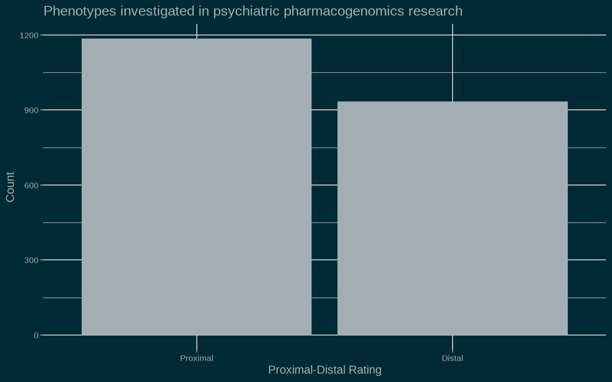

## 3.2 Assigning Country and Cohort

We also created a variable that identified the country and cohort of that the sample came from to account for sharing of participants across studies. This is sometimes evident through named cohorts, but sometimes is inferred from the hospitals recruited from, inclusion/exclusion criteria, and the time over which recruitment took place.

```r
all_smd <- all_smd %>%
      mutate(cohort = case_when(
        grepl(pattern = "campos et al., 2022", ignore.case = T, x = Study) ~ "AGDS (Australia)",
        grepl(pattern = "bråten et al., 2020", ignore.case = T, x = Study) ~ "TDM, Diakonhjemmet Hospital (Norway)",
        grepl(pattern = "jukić et al., 2018", ignore.case = T, x = Study) ~ "TDM, Diakonhjemmet Hospital (Norway)",
        grepl(pattern = "steimer et al., 2005", ignore.case = T, x = Study) ~ "Patients (Germany)", # not specific, could include Klinikum rechts der Isar
        grepl(pattern = "hendset et al., 2009", ignore.case = T, x = Study) ~ "TDM, Diakonhjemmet Hospital (Norway)",

        grepl(pattern = "crescenti et al., 2008", ignore.case = T, x = Study) ~ "Patients (Spain)", # barca
        grepl(pattern = "kobylecki et al., 2009", ignore.case = T, x = Study) ~ "Patients (Denmark)", # Since 2003, inpatients at Sct. Hans Hospital have been genotyped for CYP2D6 and CYP2C19 polymorphisms

        grepl(pattern = "calabrò et al., 2022", ignore.case = T, x = Study) ~ "GSRD (Europe)", # Group for the Study of Resistant Depression 1) Department of Psychiatry, Erasme Hospital, Université Libre de Bruxelles, Brussels, Belgium 2) PsyPluriel, Centre Européen de Psychologie Médicale, Brussels Belgium 3) Department of Psychiatry, University Hospital Gasthuisberg, Leuven, Belgium 4)Department of Psychiatry, Institutio Scientifico H San Raffaele, Milan, Italy 5) Hopital la Salpetriere, INSERM U302, Paris, France 6) Sint-Truiden Psychiatric Center, Sint-Truiden, Belgium 7) Department of Psychiatry, Chaim Sheba Medical Center, Tel-Hashomer, Israel 8) Department of Psychiatry and Psychotherapy, Medical University of Vienna, Vienna, Austria 9) Institute of Psychiatry, University of Bologna, Bologna, Italy 10) Department of Psychiatry, Athens University Medical School, Eginition Hospital, Athens, Greece

        grepl(pattern = "piatkov et al., 2017", ignore.case = T, x = Study) ~ "Patients (Australia)", # Blacktown Mental Health Service (sydney)
        grepl(pattern = "wang et al., 2024", ignore.case = T, x = Study) ~ "Patients (China)", #third peoples hospital jiangyin city
        grepl(pattern = "jukić et al., 2019", ignore.case = T, x = Study) ~ "TDM, Diakonhjemmet Hospital (Norway)",
        grepl(pattern = "saiz-rodriguez et al., 2018", ignore.case = T, x = Study) ~ "Healthy volunteers (Spain)", # healthy volunteers from two bioequivalence clinical trials performed at the Clinical Trials Unit of Hospital Universitario de la Princesa (Madrid, Spain).
        grepl(pattern = "balibey et al., 2011", ignore.case = T, x = Study) ~ "Patients (Turkey)", # GATA Haydarpasa Military Hospital, Istanbul
        grepl(pattern = "rodrigues-silva et al., 2020", ignore.case = T, x = Study) ~ "Patients (Brazil)", # goias state
        grepl(pattern = "llerena et al., 2004a", ignore.case = T, x = Study) ~ "Patients (Spain)", # Psychiatric Hospital of Mérida (Extremadura, Spain)
        grepl(pattern = "de Leon et al., 2007", ignore.case = T, x = Study) ~ "Patients (USA)", # central kentucky
        grepl(pattern = "arranz et al., 2019", ignore.case = T, x = Study) ~ "Patients (Spain)", # (Hospital Clínic and Hospital de la Santa Creu i Sant Pau, Barcelona; Hospital Universitario, Granada)
        grepl(pattern = "chavan et al., 2018", ignore.case = T, x = Study) ~ "Patients (India)", # six centers across North India
        grepl(pattern = "hongkaew et al., 2021", ignore.case = T, x = Study) ~ "Patients (Thailand)", # Yuwaprasart Waithayopathum Child Psychiatric Hospital
        grepl(pattern = "de leon et al., 2005", ignore.case = T, x = Study) ~ "Patients (USA)", # central kentucky
        grepl(pattern = "yuce-artun et al., 2016", ignore.case = T, x = Study) ~ "Patients (Turkey)", # Schools of Medicine, Ankara University and Kırıkkale University, Turkey
        grepl(pattern = "austin-zimmerman et al., 2021", ignore.case = T, x = Study) ~ "UKBB (UK)",
        grepl(pattern = "nussbaum et al., 2014", ignore.case = T, x = Study) ~ "Patients (Romania)",
        grepl(pattern = "wang et al., 2001", ignore.case = T, x = Study) ~ "Healthy volunteers (China)", # potentially Hunan Medical University


        grepl(pattern = "hodgson et al., 2014", ignore.case = T, x = Study) ~ "GENDEP (UK)",
        grepl(pattern = "vasudev et al., 2017", ignore.case = T, x = Study) ~ "PEPP (Canada)",
        grepl(pattern = "bartecek et al., 2012", ignore.case = T, x = Study) ~ "Patients (Czech Republic)", #brno
        grepl(pattern = "choong et al., 2013", ignore.case = T, x = Study) ~ "Patients (Switzerland)", # 4 psychiatric centers in Switzerland (Lausanne, Geneva, Ko ̈nigsfelden, Marsens)
        grepl(pattern = "vanwong et al., 2016", ignore.case = T, x = Study) ~ "Patients (Thailand)", # Yuwaprasart Waithayopathum Child Psychiatric Hospital
        grepl(pattern = "vanwong et al., 2017", ignore.case = T, x = Study) ~ "Patients (Thailand)", # Yuwaprasart Waithayopathum Child Psychiatric Hospital
        grepl(pattern = "jacquenoud sirot et al., 2009", ignore.case = T, x = Study) ~ "Patients (Switzerland)", #(Konigsfelden and Prilly-Lausanne)
        grepl(pattern = "mihara et al., 2003", ignore.case = T, x = Study) ~ "Patients (Japan)", # probably Hirosaki University School of Medicine
        grepl(pattern = "han et al., 2018", ignore.case = T, x = Study) ~ "Patients (South Korea)", # two university hospitals
        grepl(pattern = "ellingrod et al., 2002", ignore.case = T, x = Study) ~ "Patients (USA)", # Mental Health Clinical Research Center at the University of Iowa
        grepl(pattern = "almoguera et al., 2013", ignore.case = T, x = Study) ~ "Patients (Spain)", # Acute Psychiatric Unit of Fundacion Jiminez Diaz Hospital
        grepl(pattern = "troost et al., 2007", ignore.case = T, x = Study) ~ "Patients (Netherlands)", # Groningen and Utrecht University Child and Adolescent Psychiatry Centers
        grepl(pattern = "huezo-diaz et al., 2012", ignore.case = T, x = Study) ~ "GENDEP (UK)",
        grepl(pattern = "strumila et al., 2021", ignore.case = T, x = Study) ~ "Patients (Lithuania)", # Vilnius University Hospital Santaros Klinikos
        grepl(pattern = "grosu et al., 2022", ignore.case = T, x = Study) ~ "CoLaus|PsyCoLaus (Switzerland)",
        grepl(pattern = "riedel et al., 2005", ignore.case = T, x = Study) ~ "Patients (Germany)", # munich ??
        grepl(pattern = "belmonte et al., 2018", ignore.case = T, x = Study) ~ "Healthy volunteers (Spain)", # Clinical Trial Unit of Hospital Universitario de la Princesa (Madrid, Spain)
        grepl(pattern = "lisbeth et al., 2016", ignore.case = T, x = Study) ~ "Patients (Belgium)", # SintNorbertus, Duffel; Broeders Alexianen, Boechout; SintAmadeus, Mortsel
        grepl(pattern = "suzuki et al., 2014", ignore.case = T, x = Study) ~ "Patients (Japan)", # ryukyus aripiprazole
        grepl(pattern = "nagai et al., 2012", ignore.case = T, x = Study) ~ "Patients (Japan)", # rukus aripiprazole
        grepl(pattern = "suzuki et al., 2011", ignore.case = T, x = Study) ~ "Patients (Japan)", # Niigata University Hospital fluvoxamine
        grepl(pattern = "kubo et al., 2007", ignore.case = T, x = Study) ~ "Healthy volunteers (Japan)", # osaka
        grepl(pattern = "gassó et al., 2013", ignore.case = T, x = Study) ~ "Healthy volunteers (Spain)", # a population control cohort (Mas 2010)
        grepl(pattern = "someya et al., 2003", ignore.case = T, x = Study) ~ "Patients (Japan)", # niigata university hospital (haloperidol)
        grepl(pattern = "brockmöller et al., 2002", ignore.case = T, x = Study) ~ "Patients (Germany)", # University Medical Center Benjamin Franklin and the University Medical Center Charite, Humboldt University, Berlin, Germany
        grepl(pattern = "mas et al., 2017", ignore.case = T, x = Study) ~ "PEPS (Spain)",
        grepl(pattern = "cabaleiro et al., 2014", ignore.case = T, x = Study) ~ "Healthy volunteers (Spain)", # healthy volunteers from two bioequivalence clinical trials performed at the Clinical Trials Unit of Hospital Universitario de la Princesa (Madrid, Spain).
        grepl(pattern = "gassó et al., 2014a", ignore.case = T, x = Study) ~ "Healthy volunteers (Spain)", # a population control cohort (Mas 2010)
        grepl(pattern = "mannheimer et al., 2014", ignore.case = T, x = Study) ~ "Patients (Sweden)", # stockholm county (described in ghotbi et al., 2010)
        grepl(pattern = "novalbos et al., 2010", ignore.case = T, x = Study) ~ "Healthy volunteers (Spain)",  # healthy volunteers from two bioequivalence clinical trials performed at the Clinical Trials Unit of Hospital Universitario de la Princesa (Madrid, Spain).
        grepl(pattern = "xiang et al., 2010", ignore.case = T, x = Study) ~ "Healthy volunteers (China)", # not specified - beijing ?
        grepl(pattern = "kang et al., 2009", ignore.case = T, x = Study) ~ "Patients (South Korea)", # not specific - seoul or yangsan hospital ?
        grepl(pattern = "cho and lee, 2006", ignore.case = T, x = Study) ~ "Healthy volunteers (South Korea)", # not specified - chonnam ?
        grepl(pattern = "kirchheiner et al., 2004", ignore.case = T, x = Study) ~ "Healthy volunteers (Germany)", # not specified
        grepl(pattern = "tsuchimine et al., 2018", ignore.case = T, x = Study) ~ "Patients (Japan)", # Hirosaki University Hospital, Ehime University Hospital, and Niigata University Hospital.
        grepl(pattern = "preskorn et al., 2009", ignore.case = T, x = Study) ~ "Healthy volunteers (USA)", # not specified (single center trial)
        grepl(pattern = "hermann et al., 2008", ignore.case = T, x = Study) ~ "TDM, Diakonhjemmet Hospital (Norway)",
        grepl(pattern = "shams et al., 2006", ignore.case = T, x = Study) ~ "Patients (Germany)", # tdm not specified but probably mainz
        grepl(pattern = "charlier et al., 2003", ignore.case = T, x = Study) ~ "Patients (Belgium)", # Psychiatric Unit of the University Hospital in Liège
        grepl(pattern = "sawamura et al., 2004", ignore.case = T, x = Study) ~ "Patients (Japan)", # niigata university hospital (paroxetine)
        grepl(pattern = "chen et al., 2015", ignore.case = T, x = Study) ~ "Healthy volunteers (China)", # peking
        grepl(pattern = "morita et al., 2000", ignore.case = T, x = Study) ~ "Patients (Japan)", # shiga / showa university hospital
        grepl(pattern = "dalén et al., 1998", ignore.case = T, x = Study) ~ "Healthy volunteers (Sweden)",
        grepl(pattern = "yue et al., 1998", ignore.case = T, x = Study) ~ "Healthy volunteers (Sweden)",
        grepl(pattern = "watanabe et al., 2008", ignore.case = T, x = Study) ~ "Patients (Japan)", # niigata university hospital (fluvoxamine)
        grepl(pattern = "katoh et al., 2010", ignore.case = T, x = Study) ~ "Patients (Japan)", # hamamatsu university hospital
        grepl(pattern = "kakihara et al., 2005", ignore.case = T, x = Study) ~ "Patients (Japan)", # University Hospital of Occupational and Environmental Health
        grepl(pattern = "roke et al., 2013", ignore.case = T, x = Study) ~ "Patients (Netherlands)", #ggz central psychiatric centre
        grepl(pattern = "sukasem et al., 2016", ignore.case = T, x = Study) ~ "Patients (Thailand)", #Yuwaprasart Waithayopathum Psychiatric Hospital
        grepl(pattern = "suzuki et al., 2013", ignore.case = T, x = Study) ~ "Patients (Japan)", # niigata university hospital (risperidone)
        grepl(pattern = "van der weide and van der weide, 2015", ignore.case = T, x = Study) ~ "Patients (Netherlands)", #ggz central psychiatric centre (SCZ)
        grepl(pattern = "yoo et al., 2011", ignore.case = T, x = Study) ~ "Healthy volunteers (South Korea)", # chonnam ?
        grepl(pattern = "wang et al., 2007", ignore.case = T, x = Study) ~ "Patients (China)", # shanghai mental health centre
        grepl(pattern = "scordo et al., 1999", ignore.case = T, x = Study) ~ "Patients (Italy)", # Centres of mental health, Azienda
```

```r
        grepl(pattern = "llerena et al., 2004b", ignore.case = T, x = Study) ~ "Patients (Spain)", # Mental health centre of don benito
        grepl(pattern = "laika et al., 2010", ignore.case = T, x = Study) ~ "Patients (Germany)", # klinikum rechts der isar (munich)
        grepl(pattern = "shimoda et al., 2002a", ignore.case = T, x = Study) ~ "Patients (Japan)", # shiga university medical science hospital
        grepl(pattern = "morinobu et al., 1997", ignore.case = T, x = Study) ~ "Patients (Japan)", # yamagata university hospital
        grepl(pattern = "schenk et al., 2010", ignore.case = T, x = Study) ~ "Patients (Netherlands)", #erasmus
        grepl(pattern = "yokono et al., 2001", ignore.case = T, x = Study) ~ "Patients (Japan)", # shiga university hospital (clomipramine)
        grepl(pattern = "bijl et al., 2008", ignore.case = T, x = Study) ~ "The Rotterdam Study (Netherlands)", #erasmus
        grepl(pattern = "hendset et al., 2007", ignore.case = T, x = Study) ~ "TDM, Diakonhjemmet Hospital (Norway)",
        grepl(pattern = "mas et al., 2012", ignore.case = T, x = Study) ~ "Patients (Spain)", # barca
        grepl(pattern = "suzuki et al., 2012", ignore.case = T, x = Study) ~ "Patients (Japan)", # niigata university hospital (risperidone)
        grepl(pattern = "thanacoody et al., 2007", ignore.case = T, x = Study) ~ "Patients (UK)", #
        grepl(pattern = "whyte et al., 2006", ignore.case = T, x = Study) ~ "Patients (USA)",
        grepl(pattern = "yagihashi et al., 2009", ignore.case = T, x = Study) ~ "Patients (Japan)", # asaka
        grepl(pattern = "sugahara et al., 2009", ignore.case = T, x = Study) ~ "Patients (Japan)", # kyushu
        grepl(pattern = "kawanishi et al., 2004", ignore.case = T, x = Study) ~ "Patients (Sweden)", # Sahlgrenska University Hospital at Molndal
        grepl(pattern = "laika et al., 2009", ignore.case = T, x = Study) ~ "Patients (Germany)", # klinikum rechts der isar (munich)
        grepl(pattern = "plesniccar et al., 2006", ignore.case = T, x = Study) ~ "Patients (Slovenia)", #
        grepl(pattern = "rau et al., 2004", ignore.case = T, x = Study) ~ "Patients (Germany)", # eppendorf
        grepl(pattern = "kohlrausch et al., 2008", ignore.case = T, x = Study) ~ "Patients (Brazil)", # porto alegre
        grepl(pattern = "zourkova & hadasova, 2002", ignore.case = T, x = Study) ~ "Patients (Czech Republic)", #brno
        grepl(pattern = "liou et al., 2004", ignore.case = T, x = Study) ~ "Patients (China)", # two hospitals in taiwan
        grepl(pattern = "suzuki et al., 2006", ignore.case = T, x = Study) ~ "Patients (Japan)", # niigata university hospital (fluvoxamine)
        grepl(pattern = "roberts et al., 2004", ignore.case = T, x = Study) ~ "Patients (New Zealand)", # christchurch
        grepl(pattern = "sugai et al., 2006", ignore.case = T, x = Study) ~ "Patients (Japan)", # niigata university hospital (paroxetine)
        grepl(pattern = "tiwari et al., 2005a", ignore.case = T, x = Study) ~ "Patients (India)", # RML hospital new dehli
        grepl(pattern = "fu et al., 2006", ignore.case = T, x = Study) ~ "Patients (China)", # guangzhou general hospital
        grepl(pattern = "azuma et al., 2012", ignore.case = T, x = Study) ~ "Healthy volunteers (Japan)",
        grepl(pattern = "nichols et al., 2011", ignore.case = T, x = Study) ~ "Healthy volunteers (USA)",
        grepl(pattern = "brandl et al., 2014", ignore.case = T, x = Study) ~ "Patients (Canada)",
        grepl(pattern = "kang et al., 2023", ignore.case = T, x = Study) ~ "Patients (China)", # beijing and guizhou (RCT)
        grepl(pattern = "dettling et al., 2000", ignore.case = T, x = Study) ~ "Patients (Germany)", # berlin (Department of Psychiatry of the Benjamin Franklin University)
        grepl(pattern = "ohara et al., 2003a", ignore.case = T, x = Study) ~ "Patients (Japan)", # minami hanamaki hospital
        grepl(pattern = "ohnuma et al., 2003", ignore.case = T, x = Study) ~ "Patients (Japan)", # juntendo koshigaya hospital
        grepl(pattern = "jerling et al., 1996", ignore.case = T, x = Study) ~ "Patients (Sweden)", # TDM Huddinge Hospital
        grepl(pattern = "van der Weide et al., 2005", ignore.case = T, x = Study) ~ "Patients (Netherlands)", # TDM, Meerkanten Hospital
        grepl(pattern = "gex-fabry et al., 2008", ignore.case = T, x = Study) ~ "Patients (Switzerland)", # geneva university hospitals
        grepl(pattern = "panagiotidis et al., 2007", ignore.case = T, x = Study) ~ "Patients (Sweden)", # stockholm county
        grepl(pattern = "nozawa et al., 2008", ignore.case = T, x = Study) ~ "Patients (Japan)", # juntendo koshigaya hospital (olz)
        grepl(pattern = "muller et al., 2012", ignore.case = T, x = Study) ~ "Patients (Canada)",
        grepl(pattern = "yin et al., 2006", ignore.case = T, x = Study) ~ "Patients (China)", # hong kong
        grepl(pattern = "jaanson et al., 2002", ignore.case = T, x = Study) ~ "Patients (Estonia)", # tartu and jamejala
        grepl(pattern = "perlis et al., 2020", ignore.case = T, x = Study) ~ "Patients (USA)",
        grepl(pattern = "bradley et al., 2018", ignore.case = T, x = Study) ~ "Patients (USA)", # multicenter
        grepl(pattern = "shan et al., 2019", ignore.case = T, x = Study) ~ "Patients (China)", # second xiangya hospital
        grepl(pattern = "tiwari et al., 2022", ignore.case = T, x = Study) ~ "GAPP-MDD (Canada)", # multicenter
        grepl(pattern = "cabaleiro et al., 2015", ignore.case = T, x = Study) ~ "Healthy volunteers (Spain)", # madrid -
        grepl(pattern = "ruano et al., 2020", ignore.case = T, x = Study) ~ "CYP-GUIDES (USA)", # madrid -
        grepl(pattern = "olson et al., 2017", ignore.case = T, x = Study) ~ "Patients (USA)", # north carolina
        grepl(pattern = "ferrari et al., 2012", ignore.case = T, x = Study) ~ "Patients (Italy)", # hospital of varese
        grepl(pattern = "sim et al., 2010", ignore.case = T, x = Study) ~ "STR (Sweden)", # swedish twin registry = OCTO-Twin, SATSA, Gender
        grepl(pattern = "espadaler et al., 2017", ignore.case = T, x = Study) ~ "Patients (Spain)", # madrid (any diagnosis)
        grepl(pattern = "kaur et al., 2017", ignore.case = T, x = Study) ~ "Patients (India)", # multicentre: Government Medical College and Hospital, Chandigarh, Government Medical College, Amritsar, Post Graduate Institute of Medical Sciences, Rohtak, Govt. Medical College, Srinagar, King George's Medical University, Lucknow and Swai Mann Singh Medical College, Jaipur.
        grepl(pattern = "dos santos-junior et al., 2016", ignore.case = T, x = Study) ~ "Patients (Brazil)", # campinas
        grepl(pattern = "dorado et al., 2009", ignore.case = T, x = Study) ~ "Patients (Spain)", # madrid
        grepl(pattern = "serretti et al., 2017", ignore.case = T, x = Study) ~ "Patients (Europe)", # (i) Department of Psychiatry, Erasme Hospital, Universite ́ Libre de Bruxelles, Brussels, Belgium; (ii) SintTruiden, Psychiatric center, Sint-Truiden, Belgium; (iii) Department of Psychiatry, Chaim Sheba Medical Center, Tel-Hashomer, Israel; (iv) Department of General Psychiatry, Medical University Vienna, Austria.
        grepl(pattern = "singh, 2015", ignore.case = T, x = Study) ~ "Patients (Australia)", # not specified, RCT
        grepl(pattern = "tsai et al., 2010", ignore.case = T, x = Study) ~ "Patients (China)", # tapei, taiwan # the hospitals were Chang Gung Memorial Hospital, Mackay Memorial Hospital, Far Eastern Memorial Hospital, TMU-Wan Fang Hospital and Songde branch of the Taipei City Hospital
```

```r
        ## completed cohorts up until here ##
        grepl(pattern = "aldrich et al., 2019", ignore.case = T, x = Study) ~ "Patients (USA)", # cincinatti childrens hospital
        grepl(pattern = "andreassen et al., 1997", ignore.case = T, x = Study) ~ "Nithsdale cohort (UK)", # scotland patient cohort
        grepl(pattern = "bondrescu et al., 2024", ignore.case = T, x = Study) ~ "Patients (Romania)",
        grepl(pattern = "brouwer et al., 2024", ignore.case = T, x = Study) ~ "NESDA cohort (Netherlands)",
        grepl(pattern = "cabaleiro et al., 2013", ignore.case = T, x = Study) ~ "Healthy volunteers (Spain)", # 63 healthy Caucasian volunteers who were enrolled in two bioequivalence trials. These trials were conducted in 2007 after approval by the Ethics Committee of Hospital Universitario de la Princesa (Madrid, Spain)
        grepl(pattern = "chamnanphon et al., 2022", ignore.case = T, x = Study) ~ "Patients (Thailand)", # Yuwaprasart Waithayopathum Child Psychiatric Hospital
        grepl(pattern = "cui et al., 2020", ignore.case = T, x = Study) ~ "Patients (China)", # peking university 2010 - 2011 (CAPOC)
        grepl(pattern = "czerwensky et al., 2015", ignore.case = T, x = Study) ~ "Patients (Germany)", # Patients were recruited at the psychiatric department at Klinikum rechts der Isar, Munich, Germany.
        grepl(pattern = "dalén et al., 2003", ignore.case = T, x = Study) ~ "Healthy volunteers (Sweden)", # Koreans living in Stockholm, Sweden
        grepl(pattern = "deniz et al., 2016", ignore.case = T, x = Study) ~ "Patients (Turkey)", # Patients who were admitted to Haydarpaşa Numune Training and Research Hospital Psychiatry Department with complaints of major depression between December 2012 and May 2013 were studied.
        grepl(pattern = "faraj et al., 2022", ignore.case = T, x = Study) ~  "TDM, Diakonhjemmet Hospital (Norway)", # (1) TDM of escitalopram and N-desmethyl escitalopram performed between August 2020 and September 2021, and genotyping of CYP2C19 and CYP2D6 performed between February 2009 and September 2021
        grepl(pattern = "fekete et al., 2023", ignore.case = T, x = Study) ~  "Patients (Hungary)", # Department of Psychiatry and Psychotherapy, Semmelweis University (Budapest, Hungary)
        grepl(pattern = "gassó et al., 2014b", ignore.case = T, x = Study) ~  "Patients (Spain)", # Child and Adolescent Psychiatry and Psychology Service of the Institute of Neuroscience at the Hospital Clinic in Barcelona
        grepl(pattern = "gerstenberg et al., 2003", ignore.case = T, x = Study) ~  "Patients (Japan)", # Yamagata University School of Medicine and Akita University School of Medicine
        grepl(pattern = "gressier et al., 2015", ignore.case = T, x = Study) ~  "Patients (France)",
        grepl(pattern = "he et al., 2017", ignore.case = T, x = Study) ~  "Patients (China)",  # outpatient departments in three general hospitals and one psychiatric hospital in Tianjin, China, from May 2015 to March 2016.
        grepl(pattern = "hole et al., 2023", ignore.case = T, x = Study) ~  "TDM, Diakonhjemmet Hospital (Norway)",  # The serum concentrations of paroxetine, CYP2D6 and CYP2C19 genotypes were retrospectively extracted from this database from January 2010 to September 2021.
        grepl(pattern = "islam et al., 2024", ignore.case = T, x = Study) ~  "CAN-BIND-1 study (Canada)",  # The serum concentrations of paroxetine, CYP2D6 and CYP2C19 genotypes were retrospectively extracted from this database from January 2010 to September 2021.
        grepl(pattern = "islam et al., 2022", ignore.case = T, x = Study) ~  "CAN-BIND-1 study (Canada)",  # The serum concentrations of paroxetine, CYP2D6 and CYP2C19 genotypes were retrospectively extracted from this database from January 2010 to September 2021.
        grepl(pattern = "ivanova et al., 2016", ignore.case = T, x = Study) ~  "Patients (Russia)",  #475 patients with schizophrenia hospitalized at the Department of Endogenous Disorders of the Research Institute of Mental Health, Clinic for Biological Therapy of Mental Patients of V. M. Bekhterev Psychoneurological Research Institute, and at Departments of Regional Clinical Psychiatric Hospitals of Kemerovo and Chita.
        grepl(pattern = "ivanova et al., 2015", ignore.case = T, x = Study) ~  "Patients (Russia)",  #four psychiatric centres in West Siberia (Russia)
        grepl(pattern = "Jürgens et al., 2012", ignore.case = T, x = Study) ~  "Patients (Denmark)", # 256-bed psychiatric center in the capital region of Denmark that has offered routine screening for CYP2D6 polymorphism since 2003.
        grepl(pattern = "kanahara et al., 2019", ignore.case = T, x = Study) ~  "Patients (Japan)", # three facilities (Chiba University Hospital, Shouhaku-kai Fujita Hospital, and Shoushin-kai Mobara Shinkei-ka Hospital) in Chiba Prefecture from which the patient population was drawn. Patients with schizophrenia who had been treated in any of these facilities were recruited from March to October in 2015
        grepl(pattern = "kumar et al., 2024a", ignore.case = T, x = Study) ~  "Patients (India)", # Department of Psychiatry, Sri Venkateswara Institute of Medical Sciences (SVIMS), Tirupati, India
        grepl(pattern = "kumar et al., 2024b", ignore.case = T, x = Study) ~  "Patients (India)", # Department of Psychiatry, Sri Venkateswara Institute of Medical Sciences (SVIMS), Tirupati, India
        grepl(pattern = "liao et al., 2024", ignore.case = T, x = Study) ~  "PMDEA Study (China)", # The consortium was established in 2021 with members from seventeen Chinese hospitals.
        grepl(pattern = "ma et al., 2021", ignore.case = T, x = Study) ~  "Patients (China)", # This was a phase I, multicenter, randomized, open-label, parallelgroup study. A total of 100 Chinese patients, inpatients or outpatients, with stable schizophrenia were recruited for this study using recruitment advertisements
        grepl(pattern = "mannheimer et al., 2016", ignore.case = T, x = Study) ~ "TDM, Diakonhjemmet Hospital (Norway)",
        grepl(pattern = "mihara et al., 1999", ignore.case = T, x = Study) ~ "Patients (Japan)", # hirosaki university hospital
        grepl(pattern = "nikisch et al., 2011", ignore.case = T, x = Study) ~ "Patients (Germany)", # Klinikum Fulda gAG (Department of Psychiatry and Psychotherapy, Fulda, Germany).
        grepl(pattern = "ohara et al., 2003b", ignore.case = T, x = Study) ~ "Patients (Japan)", # National Minami Hanamaki Hospital
        grepl(pattern = "ohlsson rosenborg et al., 2008", ignore.case = T, x = Study) ~ "Patients (Japan)", # National Minami Hanamaki Hospital
```

```r
        grepl(pattern = "ortega-vázquez et al., 2021", ignore.case = T, x = Study) ~ "Patients (Mexico)", # National Institute of Neurology and Neurosurgery (near xochimilco)
        grepl(pattern = "parikh et al., 2022", ignore.case = T, x = Study) ~ "GUIDED (USA)", # National Institute of Neurology and Neurosurgery (near xochimilco)
        grepl(pattern = "parkhomenko et al., 2022", ignore.case = T, x = Study) ~ "Patients (Russia)", # Moscow Research and Practical Centre on Addictions due to the diagnosis of AIPD with predominant hallucinations
        grepl(pattern = "qu et al., 2023", ignore.case = T, x = Study) ~ "Patients (China)", # Wuxi Mental Health Center
        grepl(pattern = "mihara et al., 2000", ignore.case = T, x = Study) ~ "Patients (Japan)", # hirosaki university hospital
        grepl(pattern = "roh et al., 2001", ignore.case = T, x = Study) ~ "Patients (South Korea)", # Eighty-two native Korean schizophrenic patients 632 males and 50 females) at the Inha University Hospital and Eun-Hye Mental Hospital in Incheon, Korea
        grepl(pattern = "rudå et al., 2021", ignore.case = T, x = Study) ~ "TEA (Denmark)", # The TEA trial is a Danish investigator–initiated, multicenter, randomized controlled trial in patients aged 12 to 17 years with first-episode psychosis, antipsychotic-naive, or treated for a limited period w/ ARI / QUET
        grepl(pattern = "scordo et al., 2000", ignore.case = T, x = Study) ~ "Patients (Italy)", # Among schizophrenic patients resident in a long-term psychiatric unit in Messina, Italy, a total of 119 subjectS
        grepl(pattern = "shimoda et al., 2002b", ignore.case = T, x = Study) ~ "Patients (Japan)", #   Shiga university, detailed previously in Shimoda et al.,1999; 2000)
        grepl(pattern = "solhaug et al., 2023", ignore.case = T, x = Study) ~ "TDM, Diakonhjemmet Hospital (Norway)",
        grepl(pattern = "stephens & deleon et al., 2016", ignore.case = T, x = Study) ~ "Patients (USA)", # three Kentucky psychiatric hospitals (Central State Hospital, KY, USA; Eastern State Hospital, KY, USA; Western State Hospital, KY, USA), 4532 patients were enrolled between November 2003 and December 2005 if determined to have capacity to provide written informed consent.
        grepl(pattern = "suzuki et al., 1997", ignore.case = T, x = Study) ~ "Patients (Japan)", # Hirosaki hospital 50 participants with schizophrenia from japan receiving haloperidol.
        grepl(pattern = "sychev et al., 2016", ignore.case = T, x = Study) ~ "Patients (Russia)", # 70 men with alcohol addiction, who were hospitalized in Moscow Research and Practical Centre for Narcology of the Department of Public Health.
        grepl(pattern = "taranu et al., 2017", ignore.case = T, x = Study) ~ "METADAP (France)", # Data were collected from November 2009 to March 2013 in six university psychiatry departments in France.
        grepl(pattern = "toja-camba et al., 2024", ignore.case = T, x = Study) ~ "Patients (Spain)", # i assume University Clinical Hospital of Santiago de Compostela
        grepl(pattern = "waade et al., 2021", ignore.case = T, x = Study) ~  "TDM, Diakonhjemmet Hospital (Norway)",  # Serum concentrations of flupentixol, haloperidol, perphenazine and zuclopenthixol were extracted retrospectively from this database from March 2005 to May 2019.
        grepl(pattern = "yan et al., 2020", ignore.case = T, x = Study) ~  "Patients (China)",  # Hangzhou Seventh People's Hospital
        grepl(pattern = "yang et al., 2024", ignore.case = T, x = Study) ~  "Patients (China)",  # Third People’s Hospital of Jiangyin City. The paper version of the ethics review report was signed on August 28, 2017. A total of 76 patients with chronic schizophrenia
        grepl(pattern = "zastrozhin et al., 2022", ignore.case = T, x = Study) ~  "Patients (Russia)",  # Moscow Research and Practical Centre on Addictions of the Moscow Department of Healthcare
        grepl(pattern = "zastrozhin et al., 2018", ignore.case = T, x = Study) ~  "Patients (Russia)",  # depressive disorder and comorbid alcohol use disorder who underwent inpatient treatment in Moscow Research and Practical Centre on Addictions of the Moscow Department of Healthcare.
        grepl(pattern = "zastrozhin et al., 2022b", ignore.case = T, x = Study) ~  "Patients (Russia)",  # The study involved 267 male patients. The inclusion criteria were as follows: the dual diagnosis of “Depressive episode (F32.x, according to ICD-10)” and “Mental and behavioral disorders due to use of alcohol. Dependence syndrome.
        grepl(pattern = "zastrozhin et al., 2021", ignore.case = T, x = Study) ~  "Patients (Russia)",  # 101 male patients Depressive episode and Mental and behavioral disorders due to use of alcohol. Dependence syndrome
        grepl(pattern = "zhang et al., 2021", ignore.case = T, x = Study) ~  "Healthy volunteers (China)",  # 140 healthy subjects were included in the research, enrolled from the BE trials conducted by the two sub-centers, West China Hospital Sichuan University (subjects n = 66) and First Affiliated Hospital of Hunan Medical College (subjects n = 74)
        grepl(pattern = "zhang et al., 2024", ignore.case = T, x = Study) ~  "Patients (China)",  # Inpatients were collected from June 2016 to March 2022 in real-life settings at the psychiatric department at Xi’an mental health center, Shaanxi, China.
        grepl(pattern = "zourkova & hadasova, 2002", ignore.case = T, x = Study) ~ "Patients (Czech Republic)", # Patients were screened in the University Department of Psychiatry in Brno (Czech Republic). The group included patients with residual symptoms of a depressive disorder. They were 30 outpatients with the diagnose of a first episode of a depressive disorder (n = 13) and those with a recurrent depressive disorder (n = 17) with residual symptoms of depression
        grepl(pattern = "zubiaur et al., 2021", ignore.case = T, x = Study) ~ "Healthy Volunteers (Spain)", # This work is a continuation of other studies with antipsychotics conducted at the Hospital Universitario de La Princesa. Regarding this work, all healthy volunteers participating in the present pharmacogenetic study were previously enrolled in three clinical trials performed at the Clinical Trials Unit of Hospital Universitario de La Princesa (UECHUP), Madrid (Spain) in 2018 and 2019. One of them was a multiple-dose phase-1 clinical trial (EUDRA CT: 2018 000744-26) and two of them were bioequivalence clinical trials (EUDRA CT: 2018 000994-58 and 2018 002875-16).
         grepl(pattern = "bishop et al., 2015", ignore.case = T, x = Study) ~ "Patients (USA)", # Developmental Disorders Clinic and the Neurodevelopmental Psychopharmacology Clinic at the University of Chicago and University of Illinois at Chicago Institute for Juvenile Research.
         grepl(pattern = "chou et al., 2000", ignore.case = T, x = Study) ~ "Patients (USA)", # Eastern State Hospital [ESH] in Lexington, Kentucky
         grepl(pattern = "cojocaru et al., 2024", ignore.case = T, x = Study) ~ "Patients (Romania)", # Emergency Clinical Hospital for Children Louis Turcanu, Timis, oara, the main provider of pediatric medical services in the western part of Romania, between the years 2017 and 2020
         grepl(pattern = "fedorenko et al., 2017", ignore.case = T, x = Study) ~ "Patients (Russia)", # St. Petersburg’s V.M. Bekhterev Psychoneurological Research Institute
         grepl(pattern = "hamelin et al., 1999", ignore.case = T, x = Study) ~ "Patients (USA)", # Austin State Hospital
         grepl(pattern = "kapitany et al., 1998", ignore.case = T, x = Study) ~ "Patients (Austria)", # Department of General Psychiatry, University of Vienna
         grepl(pattern = "kiss et al., 2020", ignore.case = T, x = Study) ~ "Patients (Hungary)", # Department of Psychiatry and Psychotherapy, Semmelweis University (Budapest, Hungary)
         grepl(pattern = "murphy et al., 2003", ignore.case = T, x = Study) ~ "Patients (USA)",
         grepl(pattern = "ohmori et al., 1999", ignore.case = T, x = Study) ~ "Patients (Japan)", # University of Occupational and Environmental Health
         grepl(pattern = "sagahón‐azúa et al., 2021", ignore.case = T, x = Study) ~ "Patients (Mexico)", # Central Hospital “Dr. Ignacio Morones Prieto” (HCIMP, from its Spanish acronym), in San Luis Potosí, Mexico
         grepl(pattern = "someya et al., 1999", ignore.case = T, x = Study) ~ "Patients (Japan)", # Saitama Kounan Hospital were included in the study
        grepl(pattern = "suzuki et al., 1998", ignore.case = T, x = Study) ~ "Patients (Japan)", # Hirosaki University Hospital
        grepl(pattern = "tiwari et al., 2005b", ignore.case = T, x = Study) ~ "Patients (India)", # Department of Psychiatry, RML Hospital, New Delhi
        grepl(pattern = "topić et al., 2000", ignore.case = T, x = Study) ~ "Patients (Croatia)", # “All patients were hospitalized at the Vrapˇ ce Psychiatric Hospital and required psychotropic treatment with antidepressant (clomipramine, fluoxetine, fluvoxamine) or antipsychotic (haloperidol, clozapine, thioridazine) drugs, CYP2D6 substrates.
        grepl(pattern = "uckun et al., 2015", ignore.case = T, x = Study) ~ "Healthy volunteers (Turkey)", # Information on the healthy population has previously been reported by Suzen et al. (Ankara)
        grepl(pattern = "yasui-furukori et al., 2003", ignore.case = T, x = Study) ~ "Healthy volunteers (Turkey)", # Information on the healthy population has previously been reported by Suzen et al. (Ankara)
        grepl(pattern = "walden et al., 2019", ignore.case = T, x = Study) ~ "Patients (Canada)", # All subjects were participants of a pharmacogenetic study project at the Centre for Addiction and Mental Health, Toronto (Canada). Patients were enrolled in the study by referral from their treating physician and followed up prospectively over three months at baseline, week 6 and week 12
        grepl(pattern = "fabbri et al., 2018", ignore.case = T, x = Study) ~ "GENDEP, STARD, PGRN-AMPS, GenPod (Mixed)", #
        grepl(pattern = "chen et al., 2017", ignore.case = T, x = Study) ~ "Healthy volunteers (China)", # The study protocol was approved by the Ethics Committee of Peking Union Medical College Hospital, and all subjects provided written informed consent. A total of 12 healthy Chinese men and women, aged 20 – 45 years
       grepl(pattern = "suzuki et al., 2024", ignore.case = T, x = Study) ~ "Patients (Japan)",
        # University of the Ryukyus, and included 89 Japanese schizophrenic patients. The patients were identical to those in the authors' previous study (Suzuki et al., 2014)
       grepl(pattern = "chen et al., 2021", ignore.case = T, x = Study) ~ "Patients (China)",  # Hospital of PLA Jiangsu, Changzhou
       grepl(pattern = "demirbugen oz et al., 2023", ignore.case = T, x = Study) ~ "Patients (Turkey)",  # patients between April 2018 and January 2020 at the Department of Psychiatry, Faculty of Medicine, Ankara University. The study was conducted on 112 Turkish patients who were diagnosed with schizophrenia
       grepl(pattern = "kanu et al., 2024", ignore.case = T, x = Study) ~ "Patients (USA)",  # electronic health record (EHR) at Cincinnati Children’s Hospital Medical Center (CCHMC) from January 1, 2010 to December 31, 2021. Pediatric patients (£18 years) who were prescribed oral risperidone, oral paliperidone, or intramuscular paliperidone had clinical notes regarding their medication course in their chart,
       grepl(pattern = "liou et al., 2004", ignore.case = T, x = Study) ~ "Patients (Chinese)",  # All recruited patients were chronic residents from 2 psychiatric hospitals in Taiwan. The experiments in this study were performed in the Molecular Biological Laboratory, Department of Psychiatry, Yuli Veterans Hospital, Hualien, Taiwan, ROC.
       grepl(pattern = "filipce et al., 2018", ignore.case = T, x = Study) ~ "Patients (North Macedonia)",  # Clinic of Psychiatry, Faculty of Medicine, University “Ss. Cyril and Methodius”, Skopje.
```

```r
        grepl(pattern = "prows et al., 2009", ignore.case = T, x = Study) ~ "Patients (USA)",
                  ))

all_smd$tmp <- all_smd$Study
# strict
all_smd$tmp[all_smd$Study == "Wang et al., 2024"] <- "Lu et al., 2021" # patients were people with chronic  schizophrenia recruited from Third People’s Hospital of Jiangyin City, Jiangsu Province from May 2018 to May 2019.
all_smd$tmp[all_smd$Study == "Mas et al., 2012"] <- "Crescenti et al., 2008" # participants were inpatients receiving AP therapy and were recruited from the Psychiatry Service of the Hospital Clı́nic (Barcelona, Spain) over 2002 2004.
all_smd$tmp[all_smd$Study == "de Leon et al., 2007"] <- "de Leon et al., 2005" # both samples comprise patients on Risperidone from Kentucky, uSA (describes 2007 sample as "in the context of our previous study")
all_smd$tmp[all_smd$Study == "Hodgson et al., 2014"] <- "Huezo-Diaz et al., 2012" # both escitalopram users from the GENDEP cohort
all_smd$tmp[all_smd$Study == "Hodgson et al., 2015"] <- "Huezo-Diaz et al., 2012" # also GENDEP cohort
all_smd$tmp[all_smd$Study == "Fabbri et al., 2018"] <- "Huezo-Diaz et al., 2012" # also contains the GENDEP cohort
all_smd$tmp[all_smd$Study == "Gassó et al., 2014b"] <- "Gassó et al., 2013" # both are healthy controls from a population control cohort (Mas et al., 2010)
all_smd$tmp[all_smd$Study == "Cabaleiro et al., 2014"] <- "Novalbos et al., 2010" # both are patients enrolled in bioequivilence studies trials at hospital universitario de la princesa (madrid)
all_smd$tmp[all_smd$Study == "Suzuki et al., 2024"] <- "Suzuki et al., 2014" # "Patients identical to the previous study"

# unsure
all_smd$tmp[all_smd$Study == "Nagai et al., 2012"] <- "Suzuki et al., 2014" # both from ryukus and similar years.
all_smd$tmp[all_smd$Study == "Suzuki et al., 2013"] <- "Suzuki et al., 2012" # similar numbers of patients on risperidone rom niigata
all_smd$tmp[all_smd$Study == "Vanwong et al., 2017"] <- "Vanwong et al., 2016" # similar number of patients on risperidone, similar age, and from the same hospital
all_smd$tmp[all_smd$Study == "Sukasem et al., 2016"] <- "Vanwong et al., 2016" # children on risperidone but recruited during 2012-2013 from same hospital (given range, most likely to still be children 3/4 years later.)
all_smd$tmp[all_smd$Study == "Hongkaew et al., 2021"] <- "Vanwong et al., 2016" # children on risperidone but recruited during 2017-2018 from same hospital (given range, most likely to still be children 3/4 years later.)

# all the TDMs from Diakonhjemmet Hospital (Norway). While potentially on different drugs across different years, there may be some overlap in terms of sample and will definitely be overlap in terms of procedures.
all_smd$tmp[all_smd$Study == "Hendset et al., 2009"] <- "Bråten et al., 2020"
all_smd$tmp[all_smd$Study == "Jukić et al., 2019"] <- "Bråten et al., 2020"
all_smd$tmp[all_smd$Study == "Hermann et al., 2008"] <- "Bråten et al., 2020"
all_smd$tmp[all_smd$Study == "Hendset et al., 2007"] <- "Bråten et al., 2020"
all_smd$tmp[all_smd$Study == "Faraj et al., 2022"] <- "Bråten et al., 2020"
all_smd$tmp[all_smd$Study == "Hole et al., 2023"] <- "Bråten et al., 2020"
all_smd$tmp[all_smd$Study == "Mannheimer et al., 2016"] <- "Bråten et al., 2020"
all_smd$tmp[all_smd$Study == "Solhaug et al., 2023"] <- "Bråten et al., 2020"
all_smd$tmp[all_smd$Study == "Waade et al., 2021"] <- "Bråten et al., 2020"


setDT(all_smd)[, cohort_id := .GRP, by = tmp]
all_smd$es_id <- 1:nrow(all_smd)

# setDT(all_smd)[, cohort_id_b := .GRP, by = tmp]

#all_smd$tmp <- NULL
all_smd$country <- stringr::str_extract(string = all_smd$cohort,
                                               pattern = "(?<=\\().*(?=\\))")

all_smd <- all_smd %>%
      mutate(geo = case_when(
        grepl(pattern = "australia", ignore.case = T, x = country) ~ "Oceania",
        grepl(pattern = "austria", ignore.case = T, x = country) ~ "Europe",
        grepl(pattern = "belgium", ignore.case = T, x = country) ~ "Europe",
        grepl(pattern = "brazil", ignore.case = T, x = country) ~ "South America",
        grepl(pattern = "canada", ignore.case = T, x = country) ~ "North America",
        grepl(pattern = "china", ignore.case = T, x = country) ~ "Asia",
        grepl(pattern = "croatia", ignore.case = T, x = country) ~ "Europe",
        grepl(pattern = "denmark", ignore.case = T, x = country) ~ "Europe",
        grepl(pattern = "estonia", ignore.case = T, x = country) ~ "Europe",
        grepl(pattern = "europe", ignore.case = T, x = country) ~ "Europe",
        grepl(pattern = "france", ignore.case = T, x = country) ~ "Europe",
        grepl(pattern = "germany", ignore.case = T, x = country) ~ "Europe",
        grepl(pattern = "hungary", ignore.case = T, x = country) ~ "Europe",
        grepl(pattern = "india", ignore.case = T, x = country) ~ "Asia",
        grepl(pattern = "italy", ignore.case = T, x = country) ~ "Europe",
        grepl(pattern = "japan", ignore.case = T, x = country) ~ "Asia",
        grepl(pattern = "south korea", ignore.case = T, x = country) ~ "Asia",
        grepl(pattern = "lithuania", ignore.case = T, x = country) ~ "Europe",
        grepl(pattern = "mexico", ignore.case = T, x = country) ~ "North America",
        grepl(pattern = "mixed", ignore.case = T, x = country) ~ "Mixed",
        grepl(pattern = "netherlands", ignore.case = T, x = country) ~ "Europe",
        grepl(pattern = "new zealand", ignore.case = T, x = country) ~ "Oceania",
        grepl(pattern = "north macedonia", ignore.case = T, x = country) ~ "Europe",
        grepl(pattern = "norway", ignore.case = T, x = country) ~ "Europe",
        grepl(pattern = "portugal", ignore.case = T, x = country) ~ "Europe",
        grepl(pattern = "romania", ignore.case = T, x = country) ~ "Europe",
        grepl(pattern = "russia", ignore.case = T, x = country) ~ "Europe",
        grepl(pattern = "spain", ignore.case = T, x = country) ~ "Europe",
        grepl(pattern = "sweden", ignore.case = T, x = country) ~ "Europe",
        grepl(pattern = "switzerland", ignore.case = T, x = country) ~ "Europe",
        grepl(pattern = "thailand", ignore.case = T, x = country) ~ "Asia",
        grepl(pattern = "turkey", ignore.case = T, x = country) ~ "Europe",
        grepl(pattern = "uk", ignore.case = T, x = country) ~ "Europe",
        grepl(pattern = "usa", ignore.case = T, x = country) ~ "North America"))
```

```r
all_smd$geo <- factor(all_smd$geo)
levels(all_smd$geo) <- c(levels(all_smd$geo), 'Africa')
```

## 3.3 Coding Drug and Enzyme Variables

Drug names and enzyme names were also cleaned.

```r
all_smd$drug <- stringr::str_extract(string = all_smd$Analysis, pattern = "(?<=\\().*(?=\\))")

all_smd <- all_smd %>%
    mutate(
      drug_id = case_when(
        str_detect(drug, "(?i)amitriptyline") ~ 1,
        str_detect(drug, "(?i)aripiprazole") ~ 2,
        str_detect(drug, "(?i)bromperidol") ~ 3,
        str_detect(drug, "(?i)escitalopram") ~ 7, # escitalopram comes first or else they are all classed as citalopram
        str_detect(drug, "(?i)citalopram") ~ 4,
        str_detect(drug, "(?i)clomipramine") ~ 5,
        str_detect(drug, "(?i)clozapine") ~ 6,
        str_detect(drug, "(?i)fluoxetine") ~ 8,
        str_detect(drug, "(?i)flupentixol") ~ 9,
        str_detect(drug, "(?i)fluvoxamine") ~ 10,
        str_detect(drug, "(?i)haloperidol") ~ 11,
        str_detect(drug, "(?i)imipramine") ~ 12,
        str_detect(drug, "(?i)mirtazapine") ~ 13,
        str_detect(drug, "(?i)nortriptyline") ~ 14,
        str_detect(drug, "(?i)olanzapine") ~ 15,
        str_detect(drug, "(?i)paliperidone") ~ 16,
        str_detect(drug, "(?i)paroxetine") ~ 17,
        str_detect(drug, "(?i)perphenazine") ~ 18,
        str_detect(drug, "(?i)pimozide") ~ 19,
        str_detect(drug, "(?i)quetiapine") ~ 20,
        str_detect(drug, "(?i)risperidone") ~ 21,
        str_detect(drug, "(?i)sertraline") ~ 22,
        str_detect(drug, "(?i)venlafaxine") ~ 23,
        str_detect(drug, "(?i)zuclopenthixol") ~ 24,

        str_detect(drug, "(?i)antidepressant") ~ 99,
        str_detect(drug, "(?i)antipsychotic") ~ 99,
        str_detect(drug, "(?i)drugs") ~ 99,
        str_detect(drug, "(?i)Escitalopram and Aripiprazole") ~ 99,
        str_detect(drug, "(?i)Escitalopram & Aripiprazole") ~ 99,
        str_detect(drug, "(?i)medications") ~ 99,
        str_detect(drug, "(?i)es/citalopram") ~ 99, # double check whats going on here
        str_detect(drug, "(?i)neuroleptic") ~ 99,
        str_detect(drug, "(?i)not specified") ~ 99,
        str_detect(drug, "(?i)psychiatric") ~ 99,
        str_detect(drug, "(?i)Risperidone, Aripiprazole or Olanzapine") ~ 99,
        str_detect(drug, "(?i)SSRI") ~ 99,
        str_detect(drug, "(?i)TCA") ~ 99,
        str_detect(drug, "(?i)NRI") ~ 99,
        str_detect(drug, "(?i)SNRI") ~ 99,
        str_detect(drug, "(?i)NaSSA") ~ 99,

        str_detect(drug, "(?i)all") ~ 99,
        TRUE ~ NA
      ))

all_smd$drug_id <- factor(all_smd$drug_id, levels = c(1:24, 99), labels = c("amitriptyline", "aripiprazole", "bromperidol", "citalopram",
                                                                              "clomipramine", "clozapine", "escitalopram", "fluoxetine",
                                                                              "flupentixol", "fluvoxamine", "haloperidol", "imipramine",
                                                                              "mirtazapine", "nortriptyline", "olanzapine", "paliperidone",
                                                                              "paroxetine", "perphenazine", "pimozide", "quetiapine",
                                                                              "risperidone", "sertraline", "venlafaxine",
                                                                              "zuclopenthixol", "unknown/multiple"))

all_smd <- all_smd %>%
      mutate(drug_type = case_when(
        grepl(pattern = "amitriptyline", ignore.case = T, x = drug_id) ~ "Antidepressant",
        grepl(pattern = "aripiprazole", ignore.case = T, x = drug_id) ~ "Antipsychotic",
        grepl(pattern = "bromperidol", ignore.case = T, x = drug_id) ~ "Antipsychotic",
        grepl(pattern = "citalopram", ignore.case = T, x = drug_id) ~ "Antidepressant",
        grepl(pattern = "clomipramine", ignore.case = T, x = drug_id) ~ "Antidepressant",
        grepl(pattern = "clozapine", ignore.case = T, x = drug_id) ~ "Antipsychotic",
        grepl(pattern = "escitalopram", ignore.case = T, x = drug_id) ~ "Antidepressant",
        grepl(pattern = "flupentixol", ignore.case = T, x = drug_id) ~ "Antipsychotic",
        grepl(pattern = "fluoxetine", ignore.case = T, x = drug_id) ~ "Antidepressant",
        grepl(pattern = "fluvoxamine", ignore.case = T, x = drug_id) ~ "Antidepressant",
        grepl(pattern = "haloperidol", ignore.case = T, x = drug_id) ~ "Antipsychotic",
        grepl(pattern = "imipramine", ignore.case = T, x = drug_id) ~ "Antidepressant",
        grepl(pattern = "mirtazapine", ignore.case = T, x = drug_id) ~ "Antidepressant",
        grepl(pattern = "nortriptyline", ignore.case = T, x = drug_id) ~ "Antidepressant",
        grepl(pattern = "olanzapine", ignore.case = T, x = drug_id) ~ "Antipsychotic",
        grepl(pattern = "paliperidone", ignore.case = T, x = drug_id) ~ "Antipsychotic",
        grepl(pattern = "paroxetine", ignore.case = T, x = drug_id) ~ "Antidepressant",
        grepl(pattern = "perphenazine", ignore.case = T, x = drug_id) ~ "Antipsychotic",
        grepl(pattern = "pimozide", ignore.case = T, x = drug_id) ~ "Antipsychotic",
        grepl(pattern = "quetiapine", ignore.case = T, x = drug_id) ~ "Antipsychotic",
        grepl(pattern = "risperidone", ignore.case = T, x = drug_id) ~ "Antipsychotic",
        grepl(pattern = "sertraline", ignore.case = T, x = drug_id) ~ "Antidepressant",
        grepl(pattern = "venlafaxine", ignore.case = T, x = drug_id) ~ "Antidepressant",
        grepl(pattern = "zuclopenthixol", ignore.case = T, x = drug_id) ~ "Antipsychotic",
        grepl(pattern = "unknown/multiple", ignore.case = T, x = drug_id) ~ "Unknown/Multiple",
      ))
```

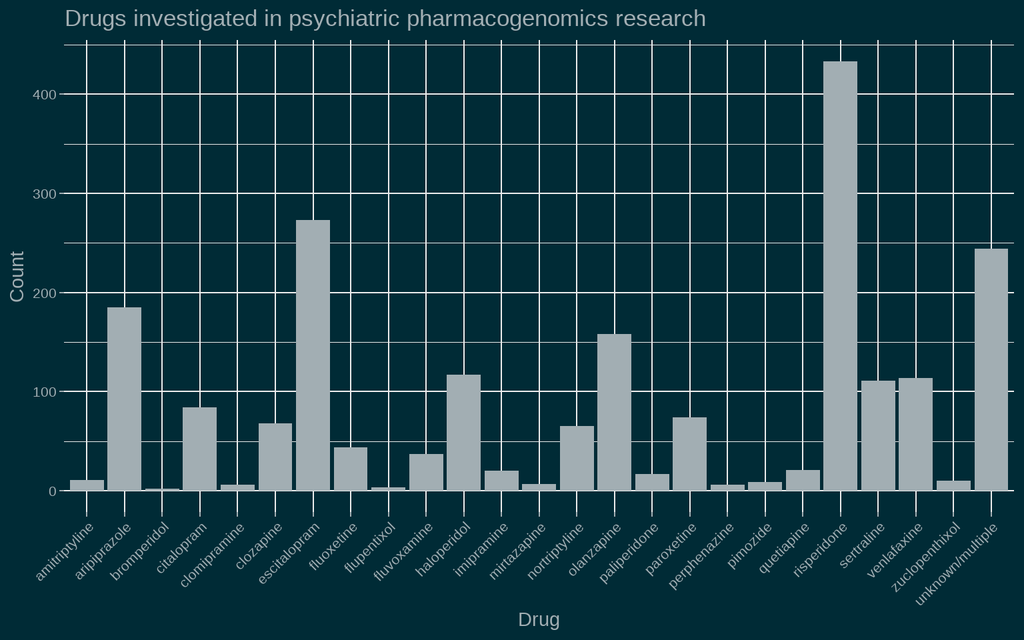

```r
all_smd$enzyme <- stringr::str_extract(string = all_smd$Analysis,
                                               pattern = "CYP\\w{2,4}")

all_smd$enzyme <- as.factor(all_smd$enzyme)

all_smd$Analysis <- str_squish(all_smd$Analysis)

all_smd <- all_smd %>%
      mutate(mp = case_when(
        grepl(pattern = "IM/PM", ignore.case = F, x = Analysis) ~ NA,
        grepl(pattern = "IM/EM", ignore.case = F, x = Analysis) ~ NA,
        grepl(pattern = "PM/IM", ignore.case = F, x = Analysis) ~ NA,
        grepl(pattern = "RM/UM", ignore.case = F, x = Analysis) ~ NA,
        grepl(pattern = "UM/EM", ignore.case = F, x = Analysis) ~ NA,
        grepl(pattern = "EM/IM", ignore.case = F, x = Analysis) ~ NA,
        grepl(pattern = "IM/IM", ignore.case = F, x = Analysis) ~ NA,
        grepl(pattern = "UM/PM", ignore.case = F, x = Analysis) ~ NA,
        grepl(pattern = "EM/PM", ignore.case = F, x = Analysis) ~ NA,
        grepl(pattern = "IM/PM", ignore.case = F, x = Analysis) ~ NA,
        grepl(pattern = "PM/PM", ignore.case = F, x = Analysis) ~ NA,

        grepl(pattern = "CYP2B6 PM", ignore.case = F, x = Analysis) ~ "PM",
        grepl(pattern = "CYP2B6 IM", ignore.case = F, x = Analysis) ~ "IM",
        grepl(pattern = "CYP2C9 PM", ignore.case = F, x = Analysis) ~ "PM",
        grepl(pattern = "CYP2C9 IM", ignore.case = F, x = Analysis) ~ "IM",
        grepl(pattern = "CYP2C19 PM", ignore.case = F, x = Analysis) ~ "PM",
        grepl(pattern = "CYP2C19 IM", ignore.case = F, x = Analysis) ~ "IM",
        grepl(pattern = "CYP2C19 RM", ignore.case = F, x = Analysis) ~ "RM",
        grepl(pattern = "CYP2C19 UM", ignore.case = F, x = Analysis) ~ "UM",
        grepl(pattern = "CYP2D6 PM", ignore.case = F, x = Analysis) ~ "PM",
        grepl(pattern = "CYP2D6 IM", ignore.case = F, x = Analysis) ~ "IM",
        grepl(pattern = "CYP2D6 UM", ignore.case = F, x = Analysis) ~ "UM",
        grepl(pattern = "CYP2D6 PC PM", ignore.case = F, x = Analysis) ~ "PM",
        grepl(pattern = "CYP2D6 PC IM", ignore.case = F, x = Analysis) ~ "IM",
        grepl(pattern = "CYP2D6 PC UM", ignore.case = F, x = Analysis) ~ "UM",
        grepl(pattern = "CYP3A5 PM", ignore.case = F, x = Analysis) ~ "PM",
        grepl(pattern = "CYP3A5 IM", ignore.case = F, x = Analysis) ~ "IM",

        ))


all_smd <- all_smd %>%
      mutate(mp_class = case_when(
        grepl(pattern = "IM", ignore.case = F, x = mp) ~ "slow",
        grepl(pattern = "PM", ignore.case = F, x = mp) ~ "slow",
        grepl(pattern = "RM", ignore.case = F, x = mp) ~ "fast",
        grepl(pattern = "UM", ignore.case = F, x = mp) ~ "fast",
        ))

all_smd <- all_smd %>%
      mutate(enzyme_type = case_when(
        grepl(pattern = "CYP1A2", ignore.case = T, x = enzyme) ~ "CYP1A2",
        grepl(pattern = "CYP2B6", ignore.case = T, x = enzyme) ~ "CYP2B6",
        grepl(pattern = "CYP2C19", ignore.case = T, x = enzyme) ~ "CYP2C19",
        grepl(pattern = "CYP2C9", ignore.case = T, x = enzyme) ~ "CYP2C9",
        grepl(pattern = "CYP2D6", ignore.case = T, x = enzyme) ~ "CYP2D6",
        grepl(pattern = "CYP3A5", ignore.case = T, x = enzyme) ~ "CYP3A4/5",
        grepl(pattern = "CYP3A4", ignore.case = T, x = enzyme) ~ "CYP3A4/5"))

all_smd$mp <- as.factor(all_smd$mp)
all_smd$mp_class <- as.factor(all_smd$mp_class)
```

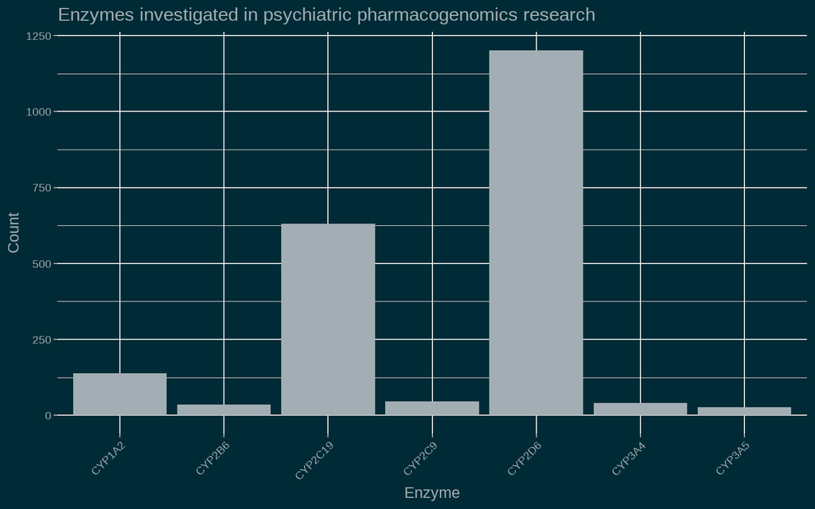

Referencing information was merged with the dataset and then the completed data set was saved as `all_smd.Rdata`.

```r
all_refs <- readxl::read_xlsx(path = "archives.xlsx", sheet = 5)

all_smd <- left_join(all_smd, all_refs, by = "Study")
```

```r
#all_smd <- all_smd %>% filter(SMD < 5 & SMD > -5)

save(all_smd, file = "all_smds.RData")
```

This table shows an overview of the analyses included in the `all_smd.Rdata` dataset.

```r
all_smd %>%
  tbl_summary(include = c(SMD, absmd, Total_N, rating), statistic = list(
      all_continuous() ~ "{mean} ({sd}) [{median}, {p25} - {p75}] ",
      all_categorical() ~ "{n} ({p}%)"
    ), digits =  all_continuous() ~ 1, label = list(SMD ~ "SMD", absmd ~ "Absolute SMD", Total_N ~ "Sample Size", rating ~ "Outcome")) %>%
  modify_header(
    label = "Variable",
    stat_0 = "Mean (SD) [Median, IQR]; n (%)")
```

| Variable | Mean (SD) [Median, IQR]; n (%)<sup>1</sup> |
| --- | --- |
| SMD | 0.2 (1.1) [0.1, -0.3 - 0.5] |
| Absolute SMD | 0.6 (0.9) [0.4, 0.1 - 0.8] |
| Sample Size | 319.1 (1,058.0) [70.0, 40.0 - 156.0] |
| Outcome |  |
| Proximal | 1,185 (56%) |
| Distal | 934 (44%) |

<sup>1</sup> Mean (SD) [Median, Q1 - Q3] ; n (%)

The studies used in this data set are summarised below:

```r
archives <- readxl::read_xlsx(path = "archives.xlsx", sheet = 1)

df <- archives %>% dplyr::select(c("Author", "Year", "Effect Measure", "Error Measure", "Calculations", "PGx Measure", "Drug", "Enzyme"))

#df <- na.omit(df)

DT::datatable(df)
```

|  | Author | Year | Effect Measure | Error Measure | Calculations | PGx Measure | Drug | Enzyme |
| --- | --- | --- | --- | --- | --- | --- | --- | --- |
| 1 | Campos | 2022 | Beta | SE | beta &gt; t | MP | Antidepressants (Sertraline, Citalopram, Escitalopram) | CYP2C19 |
| 2 | Bråten | 2020 | Mean | CI | SE &gt; SD | MP | Sertraline | CYP2C19 |
| 3 | Bråten | 2020 | Mean | SD | NA | MP | Sertraline | CYP2C19 |
| 4 | Bråten | 2020 | OR | CI | SE | MP | Sertraline | CYP2C19 |
| 5 | Jukić | 2018 | Mean | CI | SE &gt; SD | Genotypes | Escitalopram | CYP2C19 |
| 6 | Jukić | 2018 | OR | CI | SE | Genotypes | Escitalopram | CYP2C19 |
| 7 | Jukić | 2018 | Mean | SD | NA | Genotypes | Escitalopram | CYP2C19 |
| 8 | Steimer | 2005 | Observations | NA | NA | Allele functionality | Amitryptline | CYP2C19, CYP2D6 |
| 9 | Hendset | 2009 | Mean | SD | NA | Allele functionality | Risperidone | CYP2D6 |
| 10 | Crescenti | 2008 | OR | CI | SE | MP | Antipsychotics | CYP2D6 |

[output cut: 197 more lines]

# 4 Exclusions

A total of 575 papers were sought for retrieval; (N = 403 from the initial search; N = 172 from citation searching). Of these, 554 were assessed for eligibility (could not access 17 studies from the initial search and 4) from citation searching. In total, 370 studies were excluded with reasons and frequency for exclusion (total) provided below. In the end, we had 184 studies.

- Article type not of interest (N = 95)
- Language (N = 6)
- Methodological reasons (N = 77)
- Outcome , medication, or enzyme not of interest (N = 97)
- Results not reported, insufficient or unclear data/sample (N = 95)

```r
DT::datatable(all_definitions, colnames = c("Code", "Definition"))
```

|  | Code | Definition |
| --- | --- | --- |
| 1 | ART | Article type not of interest |
| 2 | CNA | Could not access article |
| 3 | LANG | Language |
| 4 | MD | Methodological reasons |
| 5 | OME | Outcome, medication, or enzyme not of interest |
| 6 | RES | Results not reported, insufficient or unclear data or sample |

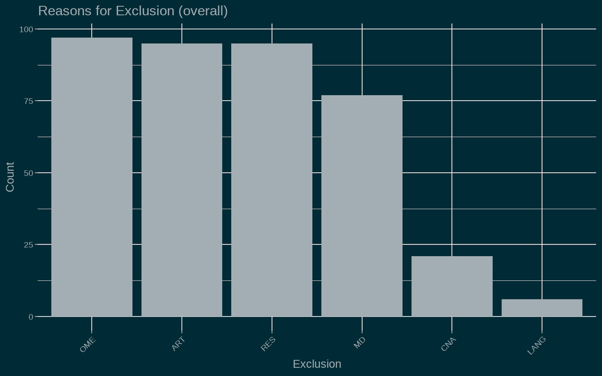

```r
exclusion_codes <- all_exclusions$`Exclusion code`
exclusion_codes <- unlist(strsplit(exclusion_codes,",")) %>% str_trim()
excl <- as.data.frame(exclusion_codes)

excl <- na.omit(excl)

exclusion_codes <- all_exclusions$overall
exclusion_codes <- unlist(strsplit(exclusion_codes,",")) %>% str_trim()
excl <- as.data.frame(exclusion_codes)
excl <- na.omit(excl)

p2 <- ggplot(excl, aes(x = fct_infreq(exclusion_codes))) +
  geom_bar() +
  labs(title = "Reasons for Exclusion (overall)") +
  xlab("Exclusion") +
  ylab("Count") +
  theme_minimal() +
  theme(axis.title = element_text(colour = "#A2AEB3"),
        axis.text.x = element_text(colour = "#A2AEB3", size = 8, angle = 45, vjust = 1, hjust=1),
        axis.text.y = element_text(colour = "#A2AEB3", size = 8),
        axis.ticks = element_line(colour = "#A2AEB3"),
        plot.title = element_text(colour = "#A2AEB3"))

p2
```

The year each study was published is also shown below:

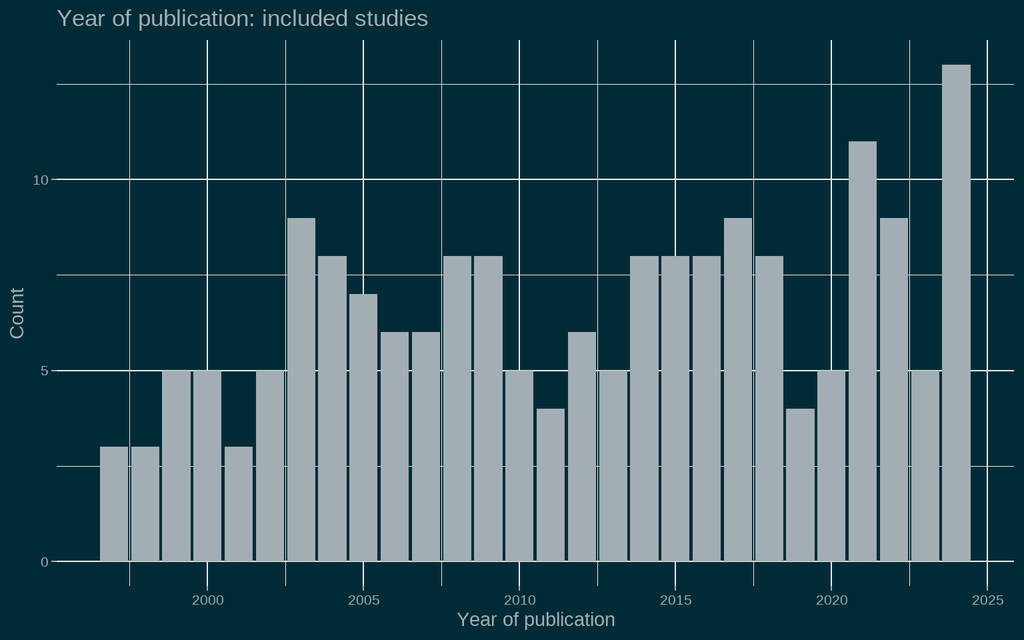

```r
plot_dates <- unique(used$key)
plot_dates <- as.data.frame(str_extract(plot_dates, "(?<=_)[0-9]+"))
colnames(plot_dates) <- "date"

yr <- as.Date(as.character(plot_dates$date), format = "%Y")
y <- year(yr)
plot_dates <- as.data.frame(y)

ggplot(plot_dates, aes(x = y)) +
  geom_bar() +
  labs(title = "Year of publication: included studies") +
  xlab("Year of publication") +
  ylab("Count") +
  theme_minimal() +
  theme(axis.title = element_text(colour = "#A2AEB3"),
        axis.text.x = element_text(colour = "#A2AEB3", size = 8),
        axis.text.y = element_text(colour = "#A2AEB3", size = 8),
        axis.ticks = element_line(colour = "#A2AEB3"),
        plot.title = element_text(colour = "#A2AEB3"))
```

# References

Aldrich, Stacey L., Ethan A. Poweleit, Cynthia A. Prows, Lisa J. Martin, Jeffrey R. Strawn, and Laura B. Ramsey. 2019. “Influence of CYP2C19 Metabolizer Status on Escitalopram/Citalopram Tolerability and Response in Youth With Anxiety and Depressive Disorders.” *Frontiers in Pharmacology* 10 (February): 99. https://doi.org/10.3389/fphar.2019.00099.

Almoguera, Berta, Rosa Riveiro-Alvarez, Jorge Lopez-Castroman, Pedro Dorado, Concepción Vaquero-Lorenzo, José Fernandez-Piqueras, Adrián LLerena, et al. 2013. “CYP2D6 Poor Metabolizer Status Might Be Associated with Better Response to Risperidone Treatment.” *Pharmacogenetics and Genomics* 23 (11): 627. https://doi.org/10.1097/FPC.0b013e3283659a94.

Andreassen, Ole A., T. MacEwan, Anne-Karin Gulbrandsen, Robin G. McCreadie, and V. M. Steen. 1997. “Non-Functional CYP2D6 Alleles and Risk for Neuroleptic-Induced Movement Disorders in Schizophrenic Patients.” *Psychopharmacology* 131 (2): 174–79. https://doi.org/10.1007/s002130050281.

Balibey, Hakan, Cengiz Basoglu, Stefan Lundgren, Melih O. Babaoglu, Umit Yasar, Hasan Herken, Anders Rane, Atilla Bozkurt, and Mesut Cetin. 2011. “CYP1A2*1F Polymorphism Decreases Clinical Response to Clozapine in Patients with Schizophrenia.” *Klinik Psikofarmakoloji Bülteni-Bulletin of Clinical Psychopharmacology* 21 (2): 93–99. https://doi.org/10.5455/bcp.20110622071701.

Belmonte, Carmen, Dolores Ochoa, Manuel Román, Miriam Saiz-Rodríguez, Aneta Wojnicz, Clara Isabel Gómez-Sánchez, Samuel Martín-Vílchez, and Francisco Abad-Santos. 2018. “Influence of 2D6, 3A4, 3A5 and 1 Polymorphisms on Pharmacokinetics and Safety of Aripiprazole in Healthy Volunteers.” *Basic & Clinical Pharmacology & Toxicology* 122 (6): 596–605. https://doi.org/10.1111/bcpt.12960.

Bijl, Monique J., Loes E. Visser, Albert Hofman, Arnold G. Vulto, Teun Van Gelder, Bruno H. Ch. Stricker, and Ron H. N. Van Schaik. 2008. “Influence of the CYP2D6*4 Polymorphism on Dose, Switching and Discontinuation of Antidepressants.” *British Journal of Clinical Pharmacology* 65 (4): 558–64. https://doi.org/10.1111/j.1365-2125.2007.03052.x.

Bishop, Jeffrey R., Fedra Najjar, Leah H. Rubin, Stephen J. Guter, Thomas Owley, Matthew W. Mosconi, Suma Jacob, and Edwin H. Cook. 2015. “Escitalopram Pharmacogenetics: CYP2C19 Relationships with Dosing and Clinical Outcomes in Autism Spectrum Disorder.” *Pharmacogenetics and Genomics* 25 (11): 548–54. https://doi.org/10.1097/FPC.0000000000000173.

Bondrescu, Mariana, Liana Dehelean, Simona Farcas, Patricia Alexandra Dragan, Carla Andreea Podaru, Laura Popa, and Nicoleta Andreescu. 2024. “Into a Deeper Understanding of CYP2D6’s Role in Risperidone Monotherapy and the Potential Side Effects in Schizophrenia Spectrum Disorders.” *International Journal of Molecular Sciences* 25 (12): 6350. https://doi.org/10.3390/ijms25126350.

Brandl, E. J., A. K. Tiwari, X. Zhou, J. Deluce, J. L. Kennedy, D. J. Müller, and M. A. Richter. 2014. “Influence of CYP2D6 and CYP2C19 Gene Variants on Antidepressant Response in Obsessive-Compulsive Disorder.” *The Pharmacogenomics Journal* 14 (2): 176–81. https://doi.org/10.1038/tpj.2013.12.

Bråten, Line S., Tore Haslemo, Marin M. Jukic, Magnus Ingelman-Sundberg, Espen Molden, and Marianne K. Kringen. 2020. “Impact of CYP2C19 Genotype on Sertraline Exposure in 1200 Scandinavian Patients.” *Neuropsychopharmacology* 45 (3): 570–76. https://doi.org/10.1038/s41386-019-0554-x.

Brockmöller, Jürgen, Julia Kirchheiner, Jürgen Schmider, Silke Walter, Christoph Sachse, Bruno Müller‐Oerlinghausen, and Ivar Roots. 2002. “The Impact of the *CYP2D6* Polymorphism on Haloperidol Pharmacokinetics and on the Outcome of Haloperidol Treatment.” *Clinical Pharmacology & Therapeutics* 72 (4): 438–52. https://doi.org/10.1067/mcp.2002.127494.

Cabaleiro, Teresa, Rosario López-Rodríguez, Manuel Román, Dolores Ochoa, Jesús Novalbos, Alberto Borobia, Antonio Carcas, and Francisco Abad-Santos. 2015. “Pharmacogenetics of Quetiapine in Healthy Volunteers: Association with Pharmacokinetics, Pharmacodynamics, and Adverse Effects.” *International Clinical Psychopharmacology* 30 (2): 82. https://doi.org/10.1097/YIC.0000000000000047.

Cabaleiro, Teresa, Dolores Ochoa, Rosario López-Rodríguez, Manuel Román, Jesús Novalbos, Carmen Ayuso, and Francisco Abad-Santos. 2014. “Effect of Polymorphisms on the Pharmacokinetics, Pharmacodynamics, and Safety of Risperidone in Healthy Volunteers.” *Human Psychopharmacology: Clinical and Experimental* 29 (5): 459–69. https://doi.org/10.1002/hup.2420.

Calabrò, Marco, Chiara Fabbri, Siegfried Kasper, Joseph Zohar, Daniel Souery, Stuart Montgomery, Diego Albani, et al. 2022. “Metabolizing Status of CYP2C19 in Response and Side Effects to Medications for Depression: Results from a Naturalistic Study.” *European Neuropsychopharmacology* 56 (March): 100–111. https://doi.org/10.1016/j.euroneuro.2022.01.008.

Campos, Adrian I., Enda M. Byrne, Brittany L. Mitchell, Naomi R. Wray, Penelope A. Lind, Julio Licinio, Sarah E. Medland, Nicholas G. Martin, Ian B. Hickie, and Miguel E. Rentería. 2022. “Impact of CYP2C19 Metaboliser Status on SSRI Response: A Retrospective Study of 9500 Participants of the Australian Genetics of Depression Study.” *The Pharmacogenomics Journal* 22 (2): 130–35. https://doi.org/10.1038/s41397-022-00267-7.

Charlier, Corinne, Franck Broly, Michel Lhermitte, Emmanuel Pinto, Marc Ansseau, and Guy Plomteux. 2003. “Polymorphisms in the CYP 2D6 Gene: Association with Plasma Concentrations of Fluoxetine and Paroxetine:” *Therapeutic Drug Monitoring* 25 (6): 738–42. https://doi.org/10.1097/00007691-200312000-00014.

Chavan, Bir S., Gurjit Kaur, Deepti Gupta, and Jitender Aneja. 2018. “A Prospective Study to Evaluate the Effect of CYP2D6 Polymorphism on Plasma Level of Risperidone and Its Metabolite in North Indian Patients with Schizophrenia.” *Indian Journal of Psychological Medicine* 40 (4): 335–42. https://doi.org/10.4103/IJPSYM.IJPSYM_83_18.

Chen, Rui, Kai Shen, and Pei Huâ©. 2017. “Polymorphism in CYP2D6 Affects the Pharmacokinetics and Dose Escalation of Paroxetine Controlled-Release Tablet in Healthy Chinese Subjects.” *Int. Journal of Clinical Pharmacology and Therapeutics* 55 (11): 853–60. https://doi.org/10.5414/CP203008.

Chen, Rui, Haotian Wang, Jun Shi, Kai Shen, and Pei Hu. 2015. “Cytochrome P450 2D6 Genotype Affects the Pharmacokinetics of Controlled-Release Paroxetine in Healthy Chinese Subjects: Comparison of Traditional Phenotype and Activity Score Systems.” *European Journal of Clinical Pharmacology* 71 (7): 835–41. https://doi.org/10.1007/s00228-015-1855-6.

Chen, Ying, Yan Li, Man-hua Liu, Yi-yan Sui, Fa-lin Qu, Li Wang, and Guang-jian Wang. 2021. “Associations of CYP1A2, CYP2D6 and CYP2C19 Gene Polymorphisms with Clozapine and Its Serum Metabolites.” *Chinese Journal of Hospital Pharmacy* 41 (18): 1855–59. https://doi.org/10.13286/j.1001-5213.2021.18.08.

Cho, Hea-Young, and Yong-Bok Lee. 2006. “Pharmacokinetics and Bioequivalence Evaluation of Risperidone in Healthy Male Subjects with Different CYP2D6 Genotypes.” *Archives of Pharmacal Research* 29 (6): 525–33. https://doi.org/10.1007/BF02969428.

Choong, Eva, Andrea Polari, Rigobert Hervais Kamdem, Nicola Gervasoni, Caesar Spisla, Eveline Jaquenoud Sirot, Graziella Giacometti Bickel, Guido Bondolfi, Philippe Conus, and Chin B. Eap. 2013. “Pharmacogenetic Study on Risperidone Long-Acting Injection: Influence of Cytochrome P450 2D6 and Pregnane X Receptor on Risperidone Exposure and Drug-Induced Side-Effects.” *Journal of Clinical Psychopharmacology* 33 (3): 289–98. https://doi.org/10.1097/JCP.0b013e31828f62cd.

Chou, Wen Hwei, Feng-Xiang Yan, Jose De Leon, John Barnhill, Thea Rogers, Maureen Cronin, Mylan Pho, et al. 2000. “Extension of a Pilot Study: Impact From the Cytochrome P450 2D6 Polymorphism on Outcome and Costs Associated With Severe Mental Illness:” *Journal of Clinical Psychopharmacology* 20 (2): 246–51. https://doi.org/10.1097/00004714-200004000-00019.

Cojocaru, Adriana, Adina Braha, Roxana Jeleriu, Nicoleta Ioana Andreescu, Maria Puiu, Luminita Ageu, Roxana Folescu, Carmen Lacramioara Zamfir, and Laura Alexandra Nussbaum. 2024. “The Implications of Cytochrome P450 2D6/CYP2D6 Polymorphism in the Therapeutic Response of Atypical Antipsychotics in Adolescents with Psychosis—A Prospective Study.” *Biomedicines* 12 (3): 494. https://doi.org/10.3390/biomedicines12030494.

Crescenti, Anna, Sergi Mas, Patricia Gassó, Eduard Parellada, Miquel Bernardo, and Amalia Lafuente. 2008. “Cyp2d6*3, *4, *5 and *6 Polymorphisms and Antipsychotic-Induced Extrapyramidal Side-Effects in Patients Receiving Antipsychotic Therapy.” *Clinical and Experimental Pharmacology and Physiology* 35 (7): 807–11. https://doi.org/10.1111/j.1440-1681.2008.04918.x.

Cui, Yuanxia, Hao Yan, Yi Su, Lifang Wang, Tianlan Lu, Dai Zhang, and Weihua Yue. 2020. “CYP2D6 Genotype-Based Dose Recommendations for Risperidone in Asian People.” *Frontiers in Pharmacology* 11 (August): 936. https://doi.org/10.3389/fphar.2020.00936.

Czerwensky, Fabian, Stefan Leucht, and Werner Steimer. 2015. “CYP1A2*1D and *1F Polymorphisms Have a Significant Impact on Olanzapine Serum Concentrations.” *Therapeutic Drug Monitoring* 37 (2): 152. https://doi.org/10.1097/FTD.0000000000000119.

Dalén, P., M-L. Dahl, H.-K. Roh, G. Tybring, M. Eichelbaum, G. R. Wilkinson, and L. Bertilsson. 2003. “Disposition of Debrisoquine and Nortriptyline in Korean Subjects in Relation to CYP2D6 Genotypes, and Comparison with Caucasians.” *British Journal of Clinical Pharmacology* 55 (6): 630–34. https://doi.org/10.1046/j.1365-2125.2003.01804.x.

Dalén, Per, Marja-Liisa Dahl, Maria Luisa Bernal Ruiz, Jan Nordin, and Leif Bertilsson. 1998. “10-Hydroxylation of Nortriptyline in White Persons with 0, 1, 2, 3, and 13 Functional CYP2D6 Genes.” *Clinical Pharmacology & Therapeutics* 63 (4): 444–52. https://doi.org/10.1016/S0009-9236(98)90040-6.

Demirbugen Oz, Merve, Fezile Ozdemir, Kenan Can Tok, Emrah Dural, Yagmur Kir, Muge Ulusoy, Mehmet Gumustas, Bora Baskak, and H. Sinan Suzen. 2023. “The Potential Role of *POR*28* and *CYP1A2*F* Genetic Variations and Lifestyle Factors on Clozapine and N-DesmethylClozapine Plasma Levels in Schizophrenia Patients.” *Expert Opinion on Drug Metabolism & Toxicology* 19 (5): 319–27. https://doi.org/10.1080/17425255.2023.2221849.

Deniz, Semanur, Mesut Sancar, Betul Okuyan, Pinar Ata, Ozlem Bingol Ozakpinar, Anil Talas, Tufan Gunes, Mecit Caliskan, and Fikret Vehbi Izzettin. 2016. “Determination of CYP2C19 Polymorphism, Side Effects, and Medication Adherence in Patients Who Have Utilized Selective Serotonin Reuptake Inhibitors.” *Klinik Psikofarmakoloji Bülteni-Bulletin of Clinical Psychopharmacology* 26 (2): 152–60. https://doi.org/10.5455/bcp.20151003060610.

Ellingrod, Vicki L., Del Miller, Susan K. Schultz, Heidi Wehring, and Stephan Arndt. 2002. “CYP2D6 Polymorphisms and Atypical Antipsychotic Weight Gain.” *Psychiatric Genetics* 12 (1): 55–58. https://doi.org/10.1097/00041444-200203000-00008.

Fabbri, Chiara, Katherine E. Tansey, Roy H. Perlis, Joanna Hauser, Neven Henigsberg, Wolfgang Maier, Ole Mors, et al. 2018. “Effect of Cytochrome *CYP2C19* Metabolizing Activity on Antidepressant Response and Side Effects: Meta-Analysis of Data from Genome-Wide Association Studies.” *European Neuropsychopharmacology* 28 (8): 945–54. https://doi.org/10.1016/j.euroneuro.2018.05.009.

Faraj, Pari, Astrid Hermansen, Espen Molden, and Kristine Hole. 2022. “Identification of Escitalopram Metabolic Ratios as Potential Biomarkers for Predicting CYP2C19 Poor Metabolizers.” *Therapeutic Drug Monitoring* 44 (6): 720. https://doi.org/10.1097/FTD.0000000000000991.

Fekete, Ferenc, Ádám Menus, Katalin Tóth, Ádám Ferenc Kiss, Annamária Minus, Dávid Sirok, Aleš Belič, Ádám Póti, Gábor Csukly, and Katalin Monostory. 2023. “CYP1A2 Expression Rather Than Genotype Is Associated with Olanzapine Concentration in Psychiatric Patients.” *Scientific Reports* 13 (1): 18507. https://doi.org/10.1038/s41598-023-45752-6.

Ferrari, Marco, Emilio Bolla, Paola Bortolaso, Camilla Callegari, Nicola Poloni, Sergio Lecchini, Simone Vender, Franca Marino, and Marco Cosentino. 2012. “Association Between CYP1A2 Polymorphisms and Clozapine-Induced Adverse Reactions in Patients with Schizophrenia.” *Psychiatry Research* 200 (2-3): 1014–17. https://doi.org/10.1016/j.psychres.2012.07.002.

Filipce, Ana, Zorica Naumovska, Aleksandra Kapedanovska Nestorovska, Zoran Sterjev, Katerina Brezovska, Jasmina Tonic-Ribarska, Aleksandra Grozdanova, Ljubica Suturkova, and Marija Raleva. 2018. “Evaluation of Correlation Between the Pharmacogenetic Profiles of Risperidone Treated Psychiatry Patients with Plasma and Urine Concentration of Risperidone and Its Active Moiety 9-OH Risperidone Determined with Optimized Bioanalytical LC Method.” *PRILOZI* 39 (2-3): 97–106. https://doi.org/10.2478/prilozi-2018-0047.

Fu, Yan, Chang-he Fan, He-huang Deng, San-hong Hu, De-peng Lv, Li-hua Li, Jun-jie Wang, and Xin-qiao Lu. 2006. “Association of CYP2D6 and CYP1A2 Gene Polymorphism with Tardive Dyskinesia in Chinese Schizophrenic Patients.” *Acta Pharmacologica Sinica* 27 (3): 328–32. https://doi.org/10.1111/j.1745-7254.2006.00279.x.

Gassó, Patricia, Sergi Mas, Katerina Papagianni, Eva Ferrando, Ramón Fernández de Bobadilla, Joan Albert Arnaiz, Miquel Bioque, Miquel Bernardo, and Amalia Lafuente. 2014. “Effect of CYP2D6 on Risperidone Pharmacokinetics and Extrapyramidal Symptoms in Healthy Volunteers: Results from a Pharmacogenetic Clinical Trial.” *Pharmacogenomics* 15 (1): 17–28. https://doi.org/10.2217/pgs.13.204.

Gassó, Patricia, Katerina Papagianni, Sergi Mas, Ramón Fernández de Bobadilla, Joan Albert Arnaiz, Miquel Bernardo, and Amalia Lafuente. 2013. “Relationship Between CYP2D6 Genotype and Haloperidol Pharmacokinetics and Extrapyramidal Symptoms in Healthy Volunteers.” *Pharmacogenomics* 14 (13): 1551–63. https://doi.org/10.2217/pgs.13.150.

Gassó, P., N. Rodríguez, S. Mas, M. Pagerols, A. Blázquez, M. T. Plana, M. Torra, L. Lázaro, and A. Lafuente. 2014. “Effect of CYP2D6, CYP2C9 and ABCB1 Genotypes on Fluoxetine Plasma Concentrations and Clinical Improvement in Children and Adolescent Patients.” *The Pharmacogenomics Journal* 14 (5): 457–62. https://doi.org/10.1038/tpj.2014.12.

Gerstenberg, Gisa, Toshiaki Aoshima, Takashi Fukasawa, Keizo Yoshida, Hitoshi Takahashi, Hisashi Higuchi, Yoshiko Murata, et al. 2003. “Effects of the CYP 2D6 Genotype and Cigarette Smoking on the Steady-State Plasma Concentrations of Fluvoxamine and Its Major Metabolite Fluvoxamino Acid in Japanese Depressed Patients:” *Therapeutic Drug Monitoring* 25 (4): 463–68. https://doi.org/10.1097/00007691-200308000-00008.

Gex-Fabry, Marianne, Chin B Eap, Beatrice Oneda, Nicola Gervasoni, Jean-Michel Aubry, Guido Bondolfi, and Gilles Bertschy. 2008. “CYP2D6 and ABCB1 Genetic Variability: Influence on Paroxetine Plasma Level and Therapeutic Response.” *Therapeutic Drug Monitoring* 30 (4): 474–82. https://doi.org/10.1097/FTD.0b013e31817d6f5d.

Gressier, F., C. Verstuyft, P. Hardy, L. Becquemont, and E. Corruble. 2015. “Response to CYP2D6 Substrate Antidepressants Is Predicted by a CYP2D6 Composite Phenotype Based on Genotype and Comedications with CYP2D6 Inhibitors.” *Journal of Neural Transmission* 122 (1): 35–42. https://doi.org/10.1007/s00702-014-1273-4.

Hamelin, Bettina A., Peter G. Dorson, Dennis Pabis, Daniel Still, Roch-H. Bouchard, Emmanuel Pourcher, Jimmy Rail, Jacques Turgeon, and M. Lynn Crismon. 1999. “CYP2D6 Mutations and Therapeutic Outcome in Schizophrenic Patients.” *Pharmacotherapy: The Journal of Human Pharmacology and Drug Therapy* 19 (9): 1057–63. https://doi.org/10.1592/phco.19.13.1057.31593.

He, Qianqian, Zhuo Yuan, Yuanyuan Liu, Jian Zhang, Hong Yan, Li Shen, Xingguang Luo, and Yong Zhang. 2017. “Correlation Between Cytochrome P450 2C19 Genetic Polymorphism and Treatment Response to Escitalopram in Panic Disorder.” *Pharmacogenetics and Genomics* 27 (8): 279. https://doi.org/10.1097/FPC.0000000000000290.

Hendset, Magnhild, Monica Hermann, Hilde Lunde, Helge Refsum, and Espen Molden. 2007. “Impact of the CYP2D6 Genotype on Steady-State Serum Concentrations of Aripiprazole and Dehydroaripiprazole.” *European Journal of Clinical Pharmacology* 63 (12): 1147–51. https://doi.org/10.1007/s00228-007-0373-6.

Hendset, Magnhild, Espen Molden, Helge Refsum, and Monica Hermann. 2009. “Impact of CYP2D6 Genotype on Steady-State Serum Concentrations of Risperidone and 9-Hydroxyrisperidone in Patients Using Long-Acting Injectable Risperidone.” *Journal of Clinical Psychopharmacology* 29 (6): 537–41. https://doi.org/10.1097/JCP.0b013e3181c17df0.

Hermann, M., M. Hendset, K. Fosaas, M. Hjerpset, and H. Refsum. 2008. “Serum Concentrations of Venlafaxine and Its Metabolites O-Desmethylvenlafaxine and N-Desmethylvenlafaxine in Heterozygous Carriers of the CYP2D6*3, *4 or *5 Allele.” *European Journal of Clinical Pharmacology* 64 (5): 483–87. https://doi.org/10.1007/s00228-007-0453-7.

Hodgson, Karen, Katherine Tansey, Mojca Zvezdana Dernovšek, Joanna Hauser, Neven Henigsberg, Wolfgang Maier, Ole Mors, et al. 2014. “Genetic Differences in Cytochrome P450 Enzymes and Antidepressant Treatment Response.” *Journal of Psychopharmacology* 28 (2): 133–41. https://doi.org/10.1177/0269881113512041.

Hole, Kristine, Tore Haslemo, and Espen Molden. 2023. “Impact of CYP2D6 Genotype on Paroxetine Serum Concentration.” *Therapeutic Drug Monitoring* 45 (5): 683. https://doi.org/10.1097/FTD.0000000000001096.

Hongkaew, Yaowaluck, Andrea Gaedigk, Bob Wilffert, Nattawat Ngamsamut, Wiranpat Kittitharaphan, Penkhae Limsila, and Chonlaphat Sukasem. 2021. “Relationship Between CYP2D6 Genotype, Activity Score and Phenotype in a Pediatric Thai Population Treated with Risperidone.” *Scientific Reports* 11 (1): 4158. https://doi.org/10.1038/s41598-021-83570-w.

Huezo-Diaz, Patricia, Nader Perroud, Edgar P Spencer, Rebecca Smith, Sarah Sim, Susanne Virding, Rudolf Uher, et al. 2012. “CYP2C19 Genotype Predicts Steady State Escitalopram Concentration in GENDEP.” *Journal of Psychopharmacology* 26 (3): 398–407. https://doi.org/10.1177/0269881111414451.

Islam, Farhana, Leen Magarbeh, Samar S. M. Elsheikh, Stefan Kloiber, Caroline W. Espinola, Venkat Bhat, Benicio N. Frey, et al. 2024. “Influence of CYP2C19, CYP2D6, and ABCB1 Gene Variants and Serum Levels of Escitalopram and Aripiprazole on Treatment-Emergent Sexual Dysfunction: A Canadian Biomarker Integration Network in Depression 1 (CAN-BIND 1) Study.” *The Canadian Journal of Psychiatry* 69 (3): 183–95. https://doi.org/10.1177/07067437231203433.

Islam, Farhana, Victoria S. Marshe, Leen Magarbeh, Benicio N. Frey, Roumen V. Milev, Claudio N. Soares, Sagar V. Parikh, et al. 2022. “Effects of CYP2C19 and CYP2D6 Gene Variants on Escitalopram and Aripiprazole Treatment Outcome and Serum Levels: Results from the CAN-BIND 1 Study.” *Translational Psychiatry* 12 (September): 366. https://doi.org/10.1038/s41398-022-02124-4.

Ivanova, S. A., M. L. Filipenko, N. M. Vyalova, E. N. Voronina, I. V. Pozhidaev, D. Z. Osmanova, M. V. Ivanov, O. Yu. Fedorenko, A. V. Semke, and N. A. Bokhan. 2016. “CYP1A2 and CYP2D6 Gene Polymorphisms in Schizophrenic Patients with Neuroleptic Drug-Induced Side Effects.” *Bulletin of Experimental Biology and Medicine* 160 (5): 687–90. https://doi.org/10.1007/s10517-016-3250-4.

Ivanova, Svetlana A., Valentina A. Toshchakova, Maxim L. Filipenko, Olga Yu Fedorenko, Evgenia G. Boyarko, Anastasia S. Boiko, Arkadiy V. Semke, Nikolay A. Bokhan, Lyubomir I. Aftanas, and Anton J. M. Loonen. 2015. “Cytochrome P450 1A2 Co-Determines Neuroleptic Load and May Diminish Tardive Dyskinesia by Increased Inducibility.” *The World Journal of Biological Psychiatry* 16 (3): 200–205. https://doi.org/10.3109/15622975.2014.995222.

Jaanson, Peeter, Toomas Marandi, Raul-Allan Kiivet, Veiko Vasar, Siiri Vään, Jan-Olof Svensson, and Marja-Liisa Dahl. 2002. “Maintenance Therapy with Zuclopenthixol Decanoate: Associations Between Plasma Concentrations, Neurological Side Effects and CYP2D6 Genotype.” *Psychopharmacology* 162 (1): 67–73. https://doi.org/10.1007/s00213-002-1059-5.

Jaquenoud Sirot, Eveline, Branka Knezevic, Gina Perla Morena, Sabine Harenberg, Beatrice Oneda, Séverine Crettol, Nicolas Ansermot, Pierre Baumann, and Chin B. Eap. 2009. “ABCB1 and Cytochrome P450 Polymorphisms: Clinical Pharmacogenetics of Clozapine.” *Journal of Clinical Psychopharmacology* 29 (4): 319–26. https://doi.org/10.1097/JCP.0b013e3181acc372.

Jukic, Marin M., Robert L. Smith, Tore Haslemo, Espen Molden, and Magnus Ingelman-Sundberg. 2019. “Effect of CYP2D6 Genotype on Exposure and Efficacy of Risperidone and Aripiprazole: A Retrospective, Cohort Study.” *The Lancet Psychiatry* 6 (5): 418–26. https://doi.org/10.1016/S2215-0366(19)30088-4.

Jukić, Marin M., Tore Haslemo, Espen Molden, and Magnus Ingelman-Sundberg. 2018. “Impact of CYP2C19 Genotype on Escitalopram Exposure and Therapeutic Failure: A Retrospective Study Based on 2,087 Patients.” *American Journal of Psychiatry* 175 (5): 463–70. https://doi.org/10.1176/appi.ajp.2017.17050550.

Jürgens, Gesche, Henrik B. Rasmussen, Thomas Werge, Kim Dalhoff, Merete Nordentoft, and Stig E. Andersen. 2012. “Does the Medication Pattern Reflect the CYP2D6 Genotype in Patients With Diagnoses Within the Schizophrenic Spectrum?” *Journal of Clinical Psychopharmacology* 32 (1): 100–105. https://doi.org/10.1097/JCP.0b013e31823f6b6a.

Kakihara, Shingo, Reiji Yoshimura, Koji Shinkai, Chima Matsumoto, Makiko Goto, Kyoko Kaji, Yasuhisa Yamada, Nobuhisa Ueda, Osamu Ohmori, and Jun Nakamura. 2005. “Prediction of Response to Risperidone Treatment with Respect to Plasma Concencentrations of Risperidone, Catecholamine Metabolites, and Polymorphism of Cytochrome P450 2D6.” *International Clinical Psychopharmacology* 20 (2): 71–78. https://doi.org/10.1097/00004850-200503000-00002.

Kanahara, Nobuhisa, Kensuke Yoshimura, Miwako Nakamura, Yasunori Oda, Motoki Watanabe, and Masaomi Iyo. 2019. “Metabolism of Risperidone by CYP2D6 and the Presence of Drug-Induced Dopamine Supersensitivity Psychosis in Patients with Schizophrenia.” *International Clinical Psychopharmacology* 34 (3): 124. https://doi.org/10.1097/YIC.0000000000000257.

Kang, Rhee-Hun, Sun-Min Jung, Kyoung-Ah Kim, Duk-Ki Lee, Hyun-Kee Cho, Bong-Joo Jung, Young-Ku Kim, et al. 2009. “Effects of CYP2D6 and CYP3A5 Genotypes on the Plasma Concentrations of Risperidone and 9-Hydroxyrisperidone in Korean Schizophrenic Patients.” *Journal of Clinical Psychopharmacology* 29 (3): 272–77. https://doi.org/10.1097/JCP.0b013e3181a289e0.

Kanu, Amarachi A., Michelle M. Johnston, Ethan A. Poweleit, Samuel E. Vaughn, Jeffrey R. Strawn, and Laura B. Ramsey. 2024. “Influence of CYP2D6 Metabolizer Status on Risperidone and Paliperidone Tolerability in Children and Adolescents.” *Journal of Child and Adolescent Psychopharmacology* 34 (1): 34–41. https://doi.org/10.1089/cap.2023.0046.

Kapitany, T., K. Meszaros, E. Lenzinger, S. D. Schindler, C. Barnas, K. Fuchs, W. Sieghart, H. N. Aschauer, and S. Kasper. 1998. “Genetic Polymorphisms for Drug Metabolism (CYP2D6) and Tardive Dyskinesia in Schizophrenia.” *Schizophrenia Research* 32 (2): 101–6. https://doi.org/10.1016/s0920-9964(98)00038-3.

Katoh, Yasuhiro, Shinya Uchida, Masayoshi Kawai, Noriyoshi Takei, Norio Mori, Junichi Kawakami, Yoshiyuki Kagawa, Shizuo Yamada, Noriyuki Namiki, and Hisakuni Hashimoto. 2010. “Effects of Cigarette Smoking and Cytochrome P450 2D6 Genotype on Fluvoxamine Concentration in Plasma of Japanese Patients.” *Biological & Pharmaceutical Bulletin* 33 (2): 285–88. https://doi.org/10.1248/bpb.33.285.

Kaur, Gurjit, Deepti Gupta, Bir Singh Chavan, Vikas Sinhmar, Rajendra Prasad, Adarsh Tripathi, P. D. Garg, et al. 2017. “Identification of Genetic Correlates of Response to Risperidone: Findings of a Multicentric Schizophrenia Study from India.” *Asian Journal of Psychiatry* 29 (October): 174–82. https://doi.org/10.1016/j.ajp.2017.07.026.

Kawanishi, Chiaki, Stefan Lundgren, Hans Agren, and Leif Bertilsson. 2004. “Increased Incidence of CYP2D6 Gene Duplication in Patients with Persistent Mood Disorders: Ultrarapid Metabolism of Antidepressants as a Cause of Nonresponse. A Pilot Study.” *European Journal of Clinical Pharmacology* 59 (11): 803–7. https://doi.org/10.1007/s00228-003-0701-4.

Kirchheiner, Julia, Hanns-Benjamin Henckel, Ingolf Meineke, Ivar Roots, and Jürgen Brockmöller. 2004. “Impact of the CYP2D6 Ultrarapid Metabolizer Genotype on Mirtazapine Pharmacokinetics and Adverse Events in Healthy Volunteers:” *Journal of Clinical Psychopharmacology* 24 (6): 647–52. https://doi.org/10.1097/01.jcp.0000145341.30547.f0.

Kiss, Ádám, Ádám Menus, Katalin Tóth, Máté Déri, Dávid Sirok, Evelyn Gabri, Ales Belic, Gábor Csukly, István Bitter, and Katalin Monostory. 2020. “Phenoconversion of CYP2D6 by Inhibitors Modifies Aripiprazole Exposure.” *European Archives of Psychiatry and Clinical Neuroscience* 270 (1): 71–82. https://doi.org/10.1007/s00406-018-0975-2.

Kobylecki, Camilla J., Klaus D. Jakobsen, Thomas Hansen, Ida V. Jakobsen, Henrik B. Rasmussen, and Thomas Werge. 2009. “CYP2D6 Genotype Predicts Antipsychotic Side Effects in Schizophrenia Inpatients: A Retrospective Matched Case-Control Study.” *Neuropsychobiology* 59 (4): 222–26. https://doi.org/10.1159/000223734.

Kohlrausch, Fabiana B., Clarissa S. Gama, Maria Inês Lobato, Paulo Belmonte-de-Abreu, Sidia M. Callegari-Jacques, Alejandro Gesteira, Francisco Barros, Angel Carracedo, and Mara H. Hutz. 2008. “Naturalistic Pharmacogenetic Study of Treatment Resistance to Typical Neuroleptics in European-Brazilian Schizophrenics.” *Pharmacogenetics and Genomics* 18 (7): 599–609. https://doi.org/10.1097/FPC.0b013e328301a763.

Kubo, Masanori, Toshiko Koue, Hiromi Maune, Tsuyoshi Fukuda, and Junichi Azuma. 2007. “Pharmacokinetics of Aripiprazole, a New Antipsychotic, Following Oral Dosing in Healthy Adult Japanese Volunteers: Influence of CYP2D6 Polymorphism.” *Drug Metabolism and Pharmacokinetics* 22 (5): 358–66. https://doi.org/10.2133/dmpk.22.358.

Kumar, B. Jeevan, Vijayakumar Thangavel Mahalingam, and Ganesh Kumar. 2024. “CYP2C19 Polymorphisms on Escitalopram Treatment Outcome in South Indian Population with Major Depressive Disorder.” *ScienceRise: Pharmaceutical Science*, no. 3 (49) (June): 70–77. https://doi.org/10.15587/2519-4852.2024.307289.

Kumar, B. J., V. T. Mahalingam, and M. G. Kumar. 2024. “The Impact of CYP2C19 Genotypes on Steady-State Plasma Concentration of Escitalopram in South Indian Population with Major Depressive Disorder.” *PHARMACIA* 71 (January): 1–6. https://doi.org/10.3897/pharmacia.71.e123645.

Laika, B., S. Leucht, S. Heres, H. Schneider, and W. Steimer. 2010. “Pharmacogenetics and Olanzapine Treatment: CYP1A2*1F and Serotonergic Polymorphisms Influence Therapeutic Outcome.” *The Pharmacogenomics Journal* 10 (1): 20–29. https://doi.org/10.1038/tpj.2009.32.

Leon, J. de, M. T. Susce, R.-M. Pan, P. J. Wedlund, M. L. Orrego, and F. J. Diaz. 2007. “A Study of Genetic (CYP2D6 and ABCB1) and Environmental (Drug Inhibitors and Inducers) Variables That May Influence Plasma Risperidone Levels.” *Pharmacopsychiatry* 40 (June): 93–102. https://doi.org/10.1055/s-2007-973836.

Leon, Jose de, Margaret T. Susce, Run-Mei Pan, Maureen Fairchild, Walter H. Koch, and Peter J. Wedlund. 2005. “The CYP2D6 Poor Metabolizer Phenotype May Be Associated With Risperidone Adverse Drug Reactions and Discontinuation.” *The Journal of Clinical Psychiatry* 66 (01): 15–27. https://doi.org/10.4088/JCP.v66n0103.

Liao, Yundan, Yutao Sun, Jing Guo, Zhewei Kang, Yaoyao Sun, Yuyanan Zhang, Jiong He, et al. 2024. “Dose Adjustment of Paroxetine Based on CYP2D6 Activity Score Inferred Metabolizer Status in Chinese Han Patients with Depressive or Anxiety Disorders: A Prospective Study and Cross-Ethnic Meta-Analysis.” *eBioMedicine* 104 (June). https://doi.org/10.1016/j.ebiom.2024.105165.

Liou, Ying-Jay, Ying-Chieh Wang, Ya-Mei Bai, Chao-Cheng Lin, Shun-Chieh Yu, Ding-Lieh Liao, Ming-Wei Lin, Jen-Yeu Chen, and I-Ching Lai. 2004. “Cytochrome P-450 2D6*10 C188T Polymorphism Is Associated with Antipsychotic-Induced Persistent Tardive Dyskinesia in Chinese Schizophrenic Patients.” *Neuropsychobiology* 49 (4): 167–73. https://doi.org/10.1159/000077360.

Lisbeth, Patteet, Haufroid Vincent, Maudens Kristof, Sabbe Bernard, Morrens Manuel, and Neels Hugo. 2016. “Genotype and Co-Medication Dependent CYP2D6 Metabolic Activity: Effects on Serum Concentrations of Aripiprazole, Haloperidol, Risperidone, Paliperidone and Zuclopenthixol.” *European Journal of Clinical Pharmacology* 72 (2): 175–84. https://doi.org/10.1007/s00228-015-1965-1.

Llerena, Adrian, Roland Berecz, Pedro Dorado, and Alfredo de la Rubia. 2004. “QTc Interval, CYP2D6 and CYP2C9 Genotypes and Risperidone Plasma Concentrations.” *Journal of Psychopharmacology*. https://doi.org/10.1177/0269881104042618.

Llerena, Adrian, Pedro Dorado, Roland Berecz, Antonio P. Gonzalez, and Eva M. Penas-Lledo. 2004. “Effect of CYP2D6 and CYP2C9 Genotypes on Fluoxetine and Norfluoxetine Plasma Concentrations During Steady-State Conditions.” *European Journal of Clinical Pharmacology* 59 (12): 869–73. https://doi.org/10.1007/s00228-003-0707-y.

Ma, Lingyue, Qian Xiang, Nan Zhao, Changqing Hu, Meng Fang, Yunlong Tan, Song Chen, et al. 2021. “Effects of *CYP2D6*, *CYP3A5*, and *ABCB1* Gene Polymorphisms on the Pharmacokinetics of Two Risperidone Long-Acting Injection Microsphere Formulations.” *Progress in Neuro-Psychopharmacology and Biological Psychiatry* 109 (July): 110241. https://doi.org/10.1016/j.pnpbp.2020.110241.

Mannheimer, Buster, Tore Haslemo, Jonatan D. Lindh, Erik Eliasson, and Espen Molden. 2016. “Risperidone and Venlafaxine Metabolic Ratios Strongly Predict a CYP2D6 Poor Metabolizing Genotype.” *Therapeutic Drug Monitoring* 38 (1): 127. https://doi.org/10.1097/FTD.0000000000000251.

Mannheimer, Buster, Johan Holm, Larissa Koukel, Leif Bertilsson, Urban Ösby, and Erik Eliasson. 2014. “Risperidone Metabolic Ratio as a Biomarker of Individual CYP2D6 Genotype in Schizophrenic Patients.” *European Journal of Clinical Pharmacology* 70 (6): 695–99. https://doi.org/10.1007/s00228-014-1664-3.

Mas, Sergi, Patricia Gassó, Mercé Torra, Miquel Bioque, Antonio Lobo, Ana González-Pinto, Maria Soledad Olmeda, et al. 2017. “Intuitive Pharmacogenetic Dosing of Risperidone According to CYP2D6 Phenotype Extrapolated from Genotype in a Cohort of First Episode Psychosis Patients.” *European Neuropsychopharmacology* 27 (7): 647–56. https://doi.org/10.1016/j.euroneuro.2017.03.012.

Mas, S., P. Gassò, S. Álvarez, E. Parellada, M. Bernardo, and A. Lafuente. 2012. “Intuitive Pharmacogenetics: Spontaneous Risperidone Dosage Is Related to CYP2D6, CYP3A5 and ABCB1 Genotypes.” *The Pharmacogenomics Journal* 12 (3): 255–59. https://doi.org/10.1038/tpj.2010.91.

Mihara, Kazuo, Tsuyoshi Kondo, Norio Yasui-Furukori, Akihito Suzuki, Masayuki Ishida, Shingo Ono, Takahiro Kubota, et al. 2003. “Effects of Various CYP2D6 Genotypes on the Steady-State Plasma Concentrations of Risperidone and Its Active Metabolite, 9-Hydroxyrisperidone, in Japanese Patients With Schizophrenia:” *Therapeutic Drug Monitoring* 25 (3): 287–93. https://doi.org/10.1097/00007691-200306000-00006.

Mihara, Kazuo, Akihito Suzuki, Tsuyoshi Kondo, Norio Yasui, Hanako Furukori, Udai Nagashima, Koichi Otani, Sunao Kaneko, and Yoshimasa Inoue. 1999. “Effects of the CYP2D6*10 Allele on the Steady-State Plasma Concentrations of Haloperidol and Reduced Haloperidol in Japanese Patients with Schizophrenia.” *Clinical Pharmacology & Therapeutics* 65 (3): 291–94. https://doi.org/10.1016/S0009-9236(99)70108-6.

Mihara, K., A. Suzuki, T. Kondo, N. Yasui, H. Furukori, U. Nagashima, S. Ono, S. Kaneko, K. Otani, and Y. Inoue. 2000. “Effect of a Genetic Polymorphism of CYP1A2 Inducibility on the Steady State Plasma Concentrations of Haloperidol and Reduced Haloperidol in Japanese Patients with Schizophrenia.” *Therapeutic Drug Monitoring* 22 (3): 245–49. https://doi.org/10.1097/00007691-200006000-00002.